# Pequenos experimentos

Prof. Frega

30/04/2025

# 1 Configurações do sistema

# 2 Lista de datas copiadas do EXCEL e resultado formatado para um script PHP

```r
"11/03/2025
18/03/2025
25/03/2025
01/04/2025
08/04/2025
15/04/2025
22/04/2025
29/04/2025
06/05/2025
13/05/2025
20/05/2025
27/05/2025
03/06/2025
10/06/2025
17/06/2025" %>% strsplit("\n") %>% unlist %>% sapply(function(x) paste0(substring(x, 7, 11), substring(x, 4, 5), substring(x, 1, 2))) %>% paste('"', ., '"', sep = "", collapse = ", ") %>% paste0("$datas = [", '"", ', ., "];") %>% cat
```

```
## $datas = ["", "20250311", "20250318", "20250325", "20250401", "20250408", "20250415", "20250422", "20250429", "20250506", "20250513", "20250520", "20250527", "20250603", "20250610", "20250617"];
```

# 3 Escrevendo equações de matemática financeira (compra e venda de imóveis)

Qual deve ser o valor de venda VV de um imóvel comprado por $600000 para que tenhamos um valor líquido igual a VL, sabendo que o lucro obtido está sujeito a 15% de IR e o valor de venda a 6% de comissão?

$$\begin{align}
\text{VL} &= \text{VV}-\text{VIR}-\text{VRCOM}\\[0.5em]
\text{VL} &= \text{VV}-(\text{VV}-600000)·0.15 -
\text{VV}·0.06\\[0.5em]
\text{VL} &= \text{VV}-0.15·\text{VV} + 90000 -
0.06·\text{VV}\\[0.5em]
\text{VL} &= 90000 +(1-0.15-0.06)·\text{VV}\\[1em]
\text{VV} &= \dfrac{\text{VL}-90000}{0.79}
\end{align}$$

# 4 Lista de alunos coletada no SIGA transformada em lista de emails para Outlook

```r
"BIANCA CAROLLO RAMOS DA SILVA  bianca.carollo@ufpr.br  Matriculado Discente Autor  Mestrado Profissional
    CESAR AUGUSTO TOMAZI    cesar.tomazi@ufpr.br    Matriculado Discente Autor  Mestrado Profissional
    ISAAC CLEMENTE COELHO   clementeisaac@ufpr.br   Matriculado Discente Autor  Mestrado Profissional
    ALINE FONTES CORDEIRO WAENGA    alinewaenga@gmail.com   Matriculado Discente Externo    Especialização
    HILDA JAQUELINE DE NOVAES FUNAKI    hilda@ufpr.br   Matriculado Discente Externo    Especialização
    LUIS GUSTAVO HAKIM LEAL luis.leal@tesouro.gov.br    Matriculado Discente Externo    Especialização
    MARINA SERIO LEAL FERREIRA  marinaslferreira@gmail.com  Matriculado Discente Externo    Especialização
    PAULO CESAR MAZZA JUSTICHECHEN  paulocmazza@gmail.com   Matriculado Discente Externo    Especialização
    PEDRO ANTONIO BOARETO   pedroaboareto@gmail.com Matriculado Discente Externo    Mestrado
    RAFAEL PICHEK   rpichek@gmail.com   Matriculado Discente Externo    Especialização
    RENATO MILHOMEM DE OLIVEIRA FILHO   rmoliveira17@gmail.com  Matriculado Discente Externo    Especialização" -> a
a %>% strsplit("\n\t") %>% unlist -> b
sapply(b, function(x){strsplit(x, "\t") %>% unlist ->a; paste0(a[1], " <", a[2], ">; ")}) %>% paste(collapse = "\n") %>% cat
```

```
## BIANCA CAROLLO RAMOS DA SILVA <bianca.carollo@ufpr.br>;
## CESAR AUGUSTO TOMAZI <cesar.tomazi@ufpr.br>;
## ISAAC CLEMENTE COELHO <clementeisaac@ufpr.br>;
## ALINE FONTES CORDEIRO WAENGA <alinewaenga@gmail.com>;
## HILDA JAQUELINE DE NOVAES FUNAKI <hilda@ufpr.br>;
## LUIS GUSTAVO HAKIM LEAL <luis.leal@tesouro.gov.br>;
## MARINA SERIO LEAL FERREIRA <marinaslferreira@gmail.com>;
## PAULO CESAR MAZZA JUSTICHECHEN <paulocmazza@gmail.com>;
## PEDRO ANTONIO BOARETO <pedroaboareto@gmail.com>;
## RAFAEL PICHEK <rpichek@gmail.com>;
## RENATO MILHOMEM DE OLIVEIRA FILHO <rmoliveira17@gmail.com>;
```

# 5 Breve análise de referências de uma tese para saber quais as mais recentes

```r
"ALDER D. A.; SILVA, J. N. M.; CARVALHO, J. O. P.; LOPES, J. C.; RUSCHEL, A. R. A estratégia de modelagem empírica de coorte e sua aplicação ao manejo florestal para a Floresta do Tapajós, Pará, Amazônia Brasileira. Bois et forêts des tropiques. v. 314, n. 4, p. 17-23, 2012.

ALMEIDA, V. B.; SILVA, J. N. M.; STEINBRENNER, M. K. A. Impacto da ocorrência de árvores ocas no rendimento da colheita de madeira na Floresta Nacional de Saracá-Taquera, Pará. Pesquisa Florestal Brasileira, v. 42, p. 1-12, 2022.

AGUNG, S.; ZUHRI, B. S. S. Analysis of the Financial Feasibility of Potential Post-Pandemic Businesses Using the Net Present Value (NPV), Internal Rate of Return (IRR), and Payback Period (PP) Methods (Case Study: MSME Environmentally Friendly Bioplastic Products. MUDIMA. v. 3, n. 7, 2023.

ANDRADE, M. B. T.; COSTA, J. N.; CARVALHO, T. O papel dos mercados internacionais madeireiros da Amazônia no cumprimento dos requerimentos de legalidade e de desempenho socioambiental. Imaflora, TimberFlow, n 15, 2024.

ANDRADE, V. H. F.; MACHADO, S. A.; FIGUEIREDO FILHO, A.; BOTOSSO, P. C.; MIRANDA, B. P.; SCHÖNGART, J. Growth models for two commercial tree species in upland forests of the Southern Brazilian Amazon. Forest Ecology and Management, v. 438, p. 215-223, 2019.

ANGELO, A.; HOSOKAWA, R. T.; BERGER, R.; CASTRO, L. H. R. Rentabilidade das exportações brasileiras de madeira tropical. Revista Floresta, v. 33, n. 1. P. 63-69, 2003.

ANGELO, H.; DE ALMEIDA, A. N.; MATRICARDI, E. A. T.; ROSETTI, C. F.; DE OLIVEIRA GASPAR, R.; MIGUEL, E. P.; DE ANDRADE VASCONCELOS, P. G. Determinants of profit in sustainable forest management in the Brazilian Amazon. African Journal of Agricultural Research, v. 11, n. 44, p. 4498-4503, 2016.

ARAÚJO, S. M. V. G. Origem e principais elementos da legislação de proteção à biodiversidade no Brasil. In: GANEM, R. S. (Org.). Conservação da biodiversidade: legislação e políticas públicas. Brasília: Edições Câmara, p. 177-222, 2010.

ARAÚJO, H. J. B. Crescimento de espécies madeireiras em uma floresta acreana e compatibilidade com a legislação florestal. Revista de Ciências Agrárias, v. 59, n. 2, p. 113-123, abr./jun. 2016.
AVILA, A. L.; SCHWARTZ, G.; RUSCHEL, A. R.; LOPES, J. C.; SILVA, J. N. M.; CARVALHO, J. O. P.; DORMANN, C. F.; MAZZEI, L.; SOARES, M. H. M.; BAUHUS, J. Recruitment, growth and recovery of commercial tree species over 30 years following logging and thinning in a tropical rain forest. Forest Ecology and Management, v. 385, p. 225-235, 2017.

ACCASTELLO, C.; BLANC, S.; MOSSO, A.; BRUN, F. Assessing the timber value: A case study in the Italian Alps. Forest Policy and Economics. v. 93, p. 36-44, 2018.

BARBIER, E. B. The concept of sustainable economic development. Environmental Conservation. v. 14, n. 2, p. 101-110, 1987.

BARROS, H. C. C. Status da comunidade arbórea remanescente 33 anos após a colheita florestal na Amazônia brasileira. Dissertação. 87 f. (Mestrado em Ciências Florestais) – Universidade Federal Rural da Amazônia, Belém, PA, 2018.

BERGER, R.; Santos, A. J.; TIMOFEICZYC JUNIOR; R.; BITTENCOURT, A. M.; SOUZA, V. S.; EISFELD, C. L. O efeito do custo da terra na rentabilidade florestal: um estudo de caso para Santa Catarina. Floresta, Curitiba, PR, v. 41, n. 3, p. 599-610, jul./set. 2011.

BERGER, R; PADILHA, J. B. Administração estratégica da produção. Universidade Federal do Paraná – UFPR. Setor de Ciências Agrárias – SCA. Depto de Economia Rural e Extensão – DERE. Curso de Pós-Graduação em Gestão Florestal: Curitiba. p.153. 2008.

BOMFIM, S. L.; D’AVIGNON, A. L. A.; SOUZA, A. N.; FONTES, P. J. P.; JOAQUIM, M. S. O potencial da concessão de florestas públicas para o desenvolvimento socioeconômico e geração de emprego na Amazônia Legal. Rev. Serv. Público, Brasília v. 67, n. 4, p. 649-670, out/dez, 2016.

BONA, D. A. O.; DA SILVA, D. A. S.; PINHEIRO, L. L.; DA SILVA, E. F.; CHICHORRO, J. F.; BASSO, M. Receita/Custo da atividade de exploração florestal em um Plano de Manejo Florestal Sustentável na Amazônia–estudo de caso. Nativa, v. 3, n. 1, p. 50-55, 2015.

BRAINARD, J.; LOVETT, A.; BATEMAN, I. Sensitivity analysis in calculating the social value of carbon sequestered in British grown Sitka spruce. Journal of Forest Economics, v. 12, n. 3, p. 201-228, 2006.

BRANCALION, P. H. S.; SILVA, E. J. V.; KLAUBERG, C. Reserva legal pode ser boa oportunidade de negócios em propriedades rurais. Visão Agrícola, n. Jan/Abr, p. 18-21, 2012. Disponível em: https://www.esalq.usp.br/visaoagricola/sites/default/files/VA10-visao-tecnica02.pdf. Acesso em: 04 mar. 2024.

BRANDES, A. F. N.; NOVELLO, B. Q.; DOMINGUES, G. A. F.; BARROS, C. F.; TAMAIO, N.  Endangered species account for 10% of Brazil’s documented timber trade. Journal for Nature Conservation, v. 55, 2020.

BRASIL. Lei nº 12.651, de 25 de maio de 2012. Dispõe sobre a proteção da vegetação nativa; altera as Leis nºs 6.938, de 31 de agosto de 1981, 9.393, de 19 de dezembro de 1996, e 11.428, de 22 de dezembro de 2006; revoga as Leis nºs 4.771, de 15 de setembro de 1965, e 7.754, de 14 de abril de 1989, e a Medida Provisória nº 2.166-67, de 24 de agosto de 2001; e dá outras providências. Diário Oficial da União, Brasília, DF, p. 1, 28 mai. 2012. Seção 1, p. 1. Disponível em: < https://www.planalto.gov.br/ccivil_03/_ato2011-2014/2012/lei/l12651.htm> Acesso em: 31 out. 2023.

BRAZ, E. M.; MATTOS, P. P.; OLIVEIRA, M. F.; BASSO, R. O. Strategies for Achieving Sustainable Logging Rate in the Brazilian Amazon Forest. Open Journal of Forestry, v. 4. n. 2, p. 100-105, 2014.

BRAZ, E. M.; MATTOS, P. P. Manejo de produção em florestas naturais da Amazônia: mitos e verdades. Nativa, Sinop, v. 03, n. 04, p. 292-295, out./dez. 2015.
BRAZ, E. M; MATTOS, P. P.; THAINES, F.; MADRON, L. D.; GARRASTAZU, M. C.; CANETTI, A.; D’OLIVEIRA, M. V. N. Criteria to be considered to achieve a sustainable second cycle in Amazon Forest. Pesquisa Florestal Brasileira, Colombo, v. 35, n. 83, p. 209-225, jul./set. 2015.

BRAZ, E. M.; SCHENEIDER, P. R.; MATTOS, P. P.; SELLE, G. L.; THAINES, F.; RIBAS, L. A.; VUADEN, E. Taxa de corte sustentável para manejo das florestas tropicais. Ciência Florestal. Santa Maria - RS. v. 22. n. 1, p. 137 - 145, 2012.
```

```r
BRAZ, E. M. Planejamento operacional da produção em Floresta Tropical. Rio Branco: Embrapa-CPAF/AC. 1997. (Embrapa-CPAF/AC – Documento n. 25).

BRIENEN, R. J. W.; ZUIDEMA, P. A. Incorporating persistent tree growth differences increases estimates of tropical timber yield. Front. Ecol. Environ., v. 5, pp. 302-306, 2007.

BUENO, G.; PAULILLO, L. F. DE O. E; MEIRELLES, J. L. F. Weighted average cost of capital and value creation of agribusiness companies listed on b3 between 2012 and 2019. Custos e Agronegocio, v. 16, n. Special Issue, p. 374–396, 2020.

CAPANEMA, V. P.; ESCADA, M. I. S.; ANDRADE, P. R.; LANDINI, L. G. Assessing logging legislation parameters and forest growth dissimilarities in the Brazilian Amazon, Forest Ecology and Management, v. 513, 2022.

CARDOSO, R. M.; MIGUEL, E. P.; SOUZA, H. J.; SOUZA, A. N.; NASCIMENTO, R. G. M. Wood volume is overestimated in the Brazilian Amazon: Why not use generic volume prediction methods in tropical forest management? Journal of Environmental Management. v. 350, 2024.

CARNEIRO, F. S.; RUSCHEL, A. R.; FREITAS, L. J. M.; PINHEIRO, K. A. O.; D'ARACE, L. M. B.; MAESTRI, M. P. Resiliência do volume de madeira de espécies comerciais em diferentes áreas experimentais na Amazônia Oriental. Revista Ibero Americana de Ciências Ambientais, v. 10, n. 6, p. 15-31, 2019.
CASAROTTO FILHO, N.; KOPITTKE, B. H.  Análise de investimentos: Manual para solução de problemas e tomadas de decisão. 12 ed. São Paulo, Atlas, 2019.

CASTRO, T. C; CARVALHO, J. O. P.; SCHWARTZ, G.; SILVA, J. N. M.; RUSCHEL, A. R.; FREITAS, L. J. M.; GOMES, J. M.; PINTO, R. S. The continuous timber production over cutting cycles in the Brazilian Amazon depends on volumes of species not harvested in previous cuts. Forest Ecology and Management. v. 490, 2021.

CHARISMA, B.; AMIR, E. Economic Value-Added Creation by Optimizing Capital Structure in Project Finance. International Journal of Applied Research in Management and Economics. v. 3, n. 2, p. 46 – 60, 2020.

CHOI, G.; HEO, E.; LEE, C. Y. Dynamic economic analysis of subsidies for new and renewable energy in South Korea. Sustainability, v. 10, n. 6, p. 1–19, 2018.

CHUDY, A. R. P.; CHUDYA, K. A.; SILVA, B. K.; CUBBAGE, F. W.; RUBILAR, R.; LORD, R. Profitability and risk sources in global timberland Investments. Forest Policy and Economics. v. 111, 2020.

CONDÉ, T. M.; TONINI, H.; HIGUCHI, N.; HIGUCHI, F. G.; LIMA, A. J. N.; BARBOSA, R. I.; PEREIRA, T. S.; HAAS, M. A. Efeitos do manejo florestal sustentável na diversidade de árvores, volumes de madeira e estoques de carbono em uma floresta ecótona no norte da Amazônia brasileira. Land Use Policy, v. 119, 2022.

CONFEDERAÇÃO NACIONAL DA INDÚSTRIA (CNI). Produção sustentável de florestas nativas: manejo florestal e industrialização da madeira: proposta de revisão do marco regulatório. Brasília: DF, 2018.

CONSELHO NACIONAL DE MEIO AMBIENTE (CONAMA). Resolução nº 406, de 2 de fevereiro de 2009. Estabelece parâmetros técnicos a serem adotados na elaboração, apresentação, avaliação técnica e execução de Plano de Manejo Florestal Sustentável - PMFS com fins madeireiros, para florestas nativas e suas formas de sucessão no bioma Amazônia. Diário Oficial da União. Brasília, DF, p. 1, 6 fev. 2009. Seção 1, p. 1. Disponível em: https://www.ibama.gov.br/component/legislacao/?view=legislacao&legislacao=114762> Acesso em: 31 out. 2023.

CONSELHO NACIONAL DE MEIO AMBIENTE (CONAMA). Regulamentação de parâmetros técnicos em PMFS no âmbito do CONAMA. Nota técnica. 2008. Disponível em: <https://conama.mma.gov.br/index.php?option=com_sisconama&task=documento.download&id=17145>. Acesso em: 10 abr. 2024.

COSTA, D. H. M.; SILVA, J. N. M.; CARVALHO, J. O. P. Crescimento de árvores em uma área de terra firme na Floresta Nacional do Tapajós após a colheita de madeira. Revista de Ciências Agrárias, n. 50, p. 63-76, jul./dez. 2008.

CRISTEA, C.; CRISTEA, M.; BIROU, I.; TÎRNOVAN, R. Economic assessment of grid-connected residential solar photovoltaic systems introduced under Romania’s new regulation. Renewable Energy, v. 162, p. 13–29, 2020.

CYSNEIROS, V. C.; PELISSARI, A. L.; MACHADO, S. A.; FILHO, A. F.; SOUZA, L. Modelos genéricos e específicos para estimativa do volume comercial em uma floresta sob concessão na Amazônia. Scientia Forestalis, v. 45, p. 295-304, 2017.

CUBBAGE, F., DAVIS, R.; FREY, G.; BEHR, D. C. Financial and Economic Evaluation Guidelines for Community Forestry Projects in Latin America. Washington, DC: Program on Forests (PROFOR). 2013.

CUBBAGE, F.; DAVISC, R.; FREY, G.; BEHRC, D. C.; SILLS, E. Financial and Economic Evaluation Guidelines for International Forestry Projects. In. Tropical Forestry Handbook. L. PANCEL, M. KOHL (Eds.), Springer, Berlin Heidelberg, Berlin, 2015.

CUONG, T.; CHINH, T. T. Q.; ZHANG, Y. Y.; XIE, Y..Economic Performance of Forest Plantations in Vietnam: Eucalyptus, Acacia mangium, and Manglietia conífera. Forests. v. 11, n. 3, 2020.

DAMODARAN, A. Betas by Sector (US). 2024. Disponível em: <https://pages.stern.nyu.edu/~adamodar/New_Home_Page/datafile/Betas.html>. Acessado em: 11 de dez. 2024.

DE GRAAF, N. R.; FILIUS, A. M.; SANTOS. A. R. H. Financial analysis of sustained forest management for timber: Perspectives for application of the CELOS managerial system in Brazilian Amazonia. Forest Ecology and Management, n. 77, p. 287-299, 2003.

DRAPER, F. C., COSTA, F. R. C., ARELLANO, G. et al. Amazon tree dominance across forest strata. Nature Ecology & Evolution, v. 5, p. 757–767, 2021.

DULSALAM, S.; S. SUHARTANA; YUNIAWATI, S.; HERNININGRUM, M.; ANDINI, S. Reduced impact logging in the dried land natural production forests in Indonesia. 2IOP Conf. Series: Earth and Environmental Science, v. 914, 2021.

DYKSTRA, D. P. The old and new of reduced impact logging. ITTO Tropical Forest Update, v. 11, n. 2, p. 3-4, 2001.

ENRÍQUEZ-DE-SALAMANCA, Á. Carbon versus Timber Economy in Mediterranean Forests. Atmosphere, v. 12, n. 746, 2021.

ESCOLANO, A. J. M. Análise da oferta e da demanda de produtos oriundos das florestas nativas dentro do Brasil - período de 1986 a 2016. 2020. 112 f. Dissertação (Mestrado em Ciências). Universidade de São Paulo/Escola Superior de Agricultura “Luiz de Queiroz”. São Paulo. 2020.
```

```r
FEARNSIDE, P. Deforestation of the Brazilian Amazon. Oxford Research Encyclopedia of Environmental Science. 2017.

FISCHER, P. W.; CULLEN, A. C.; ETTL, G. J. The Effect of Forest Management Strategy on Carbon Storage and Revenue in Western Washington: A Probabilistic Simulation of Tradeoffs. Risk Analysis, v. 37, n. 1, 2017.

FOOD AND AGRICULTURE ORGANIZATION OF THE UNITED NATIONS (FAO). The State of the World’s Forests 2022: Forest pathways for green recovery and building inclusive, resilient and sustainable economies. Rome, FAO. 2022.

FOOD AND AGRICULTURE ORGANIZATION OF THE UNITED NATIONS (FAO). Global Forest Resources Assessment 2020: Main report. Rome. 2020.

FOOD AND AGRICULTURE ORGANIZATION OF THE UNITED NATIONS (FAO). Implementing the non-legally binding instrument on all types of forests a capacity building module for the implementation of the forest instrument. 2011. Disponível em: <https://www.un.org/esa/forests/wp-content/uploads/2015/06/capacity_development_module.pdf >. Acessado em: 24 out. 2023.

FOOD AND AGRICULTURE ORGANIZATION OF THE UNITED NATIONS - FAO. Tendencias y perspectivas del sector forestal en américa latina y el caribe. Roma, 2006. Disponível em: <http://www.fao.org/3/a0470s/a0470s00.pdf>. Acesso em: 1 dez. 2023.

FONSECA, J. W. F. Análise e Decisão de Investimentos. Curitiba: IESDE Brasil S.A. 152 p.  2009.

FREY, G. E.; CHARNLEY, S.; MAKALA, J. Economic viability of community-based forest management for certified timber production in southeastern Tanzania. World Development, v. 144, 2021.

FUNDAÇÃO GETÚLIO VARGAS - FGV. Coalizão Brasil clima, floresta e agricultura: eixo II: contribuições para análise da viabilidade econômica das propostas referentes à duplicação da área de manejo florestal sustentável: resumo executivo. Rio de Janeiro: FGV/ Centro de Estudos em Sustentabilidade, 2016. Disponível em < https://repositorio.fgv.br/server/api/core/bitstreams/1ca828cb-edd9-4c0b-b7a4-ae1980bbfbb2/content > Acessado em: 14 de mar. 2024.

GAMA, J. R. V.; SOUZA, A. L.; SILVA, M. S.; VIEIRA, D. S.; OLIVEIRA, M. L. R.; FIGUEIREDO, A. E. S.; Lafetá, B. O. Financial viability of charcoal production in different forest management systems in Brazil. Kurú, v. 19, n. 44, 2022.

GHAZARYANT, A.; ASOYAN, S.; MELIK-PARSADANYAN, V. The Credit Spread: Risk-Free Rate in the Model. Theoretical and Practical Research in Economic Fields. v. 15, n 3(31), 2024.

GIDDINGS B.; HOPWOOD B.; O’BRIEN G. Environment, economy and society: fitting them together into sustainable development. Sustainable Development. v. 10, p.187–196, 2002.

GIL, A. C. Como elaborar projetos de pesquisa.  4. Ed. São Paulo: Atlas, 2002.

GITMAN, L. J. Princípios de administração financeira. 7. ed. São Paulo: Harbra, 2002.

GOUVEIA, D. M.; ARCE, J. E.; LOPES, E. S.; GUIMARAES, F. A. R.; LIMA, R. S.; PEREIRA, R. D. P. A. Optimization of storage yards in sustainable forest management in the amazon. Journal of Environmental Management, v. 372, 2024.

GUAITA-PRADAS, I.; BLASCO-RUIZ, A. Analyzing profitability and discount rates for solar PV Plants. A spanish case. Sustainability, v. 12, n. 8, 2020.

HIGUCHI, N.; SANTOS, J.; RIBEIRO, R. J.; FREITAS, J. V.; VIEIRA, G.; COIC, A. R.; MINETTE, L. J. Crescimento e Incremento de uma Floresta Amazônica de Terra Firme Manejada Experimentalmente. In: Biomassa de Nutrientes Florestais. INPA/DFID, Manaus, p. 89-132, 1997.

HIGUCHI, N. Utilização e manejo dos recursos madeireiros das florestas tropicais úmidas. Acta Amazonica. v. 24 n. 3/4, p. 275-288, 1994.

HOLMES, T. P.; BLATE, G. M.; ZWEEDE, J. C.; PEREIRA JR, R. BARRETO, P.; BOLTZ, F. Custos e benefícios financeiros da exploração florestal de impacto reduzido em comparação à exploração florestal convencional na Amazônia Oriental. Belém: Fundação Floresta Tropical, 66p. 2002.

HUMMEL, A. C. Normas de acesso ao recurso florestal na Amazônia brasileira: O caso do manejo florestal madeireiro. 2001. 101 f. Dissertação (mestrado em Ciências de Florestas Tropicais) - Instituto Nacional de pesquisa da Amazônia, Manaus, 2001.

HUMPHRIES, S.; HOLMES, T.; ANDRADE, D. F. C.; MCGRATH, D.; DANTAS, J. B. Searching for win-win forest outcomes: Learning-by-doing, financial viability, and income growth for a community-based forest management cooperative in the Brazilian Amazon. World Development, v. 125, 2020.

HUMPHRIES, S; HOLMES, T.; KAINER, K.; KOURY, C. G. G.; CRUZ, E.; ROCHA, R. M. Are community-based forest enterprises in the tropics financially viable? Case studies from the Brazilian Amazon. Ecological Economics, v. 77, p. 62-73, 2012.

INSTITUTO BRASILEIRO DE GEOGRAFIA E ESTATÍSTICA (IBGE). Divisão regional do Brasil em regiões geográficas imediatas e regiões geográficas intermediárias. IBGE, Coordenação de Geografia, Rio de Janeiro, 82 p. 2017.

INSTITUTO CHICO MENDES DE CONSERVAÇÃO DA BIODIVERSIDADE (ICMBIO). Plano de Manejo – Floresta Nacional de Caxiuanã. Volume I – Diagnóstico. 2012. Disponível em: < https://www.gov.br/icmbio/pt-br/assuntos/biodiversidade/unidade-de-conservacao/unidades-de-biomas/amazonia/lista-de-ucs/flona-de-caxiuana/arquivos/volumeI_completo.pdf> Acesso em: 31 out. 2023.

INTERNATIONAL TROPICAL TIMBER ORGANIZATION (ITTO). Decision 5 (XXVII): ITTO year 2000 objective and its promotion through public education and awareness. Twenty-seventh session. Yohokohama, Japan. 1999.

IPEADATA. EMBI+ Risco-Brasil (JPM366_EMBI366). 2024. Disponível em: < http://www.ipeadata.gov.br/ExibeSerie.aspx?serid=40940&module=M>. Acessado em: 11 de dez. 2024.

ISLAM, M. M.; AFRIN, S. TAREK, M. H., RAHMAN, M. M. Reliability and financial feasibility assessment of a community rainwater harvesting system considering precipitation variability due to climate change Journal of Environmental Management. v. 289, n. 1, 2021.

KÁNOVÁ, M.; DRÁBEK, J.; ĆURIĆ, P.; PIRC BARČIĆ, A. Quantification of Expected Return of Investment in Wood Processing Sectors in Slovakia. Forests, v. 15, n 75, 2024.

KANT, S. Extending the boundaries of forest economics. Journal of Forest Policy and Economics, v. 5, p. 39-58, 2003.
```

```r
KARIM, A. R. A.; MOHAMMAD, R. Meta-study of sensitivity analysis in solar renewable energy application. Progress in Energy and Environment. v. 23, p. 14-25, 2023.

KUKHARENKO, A. Y.; STERN, A. A.; GORSKY, M. A. The formula for the aggregated calculation of the weighted average cost of capital of companies. Entrepreneur's guide, v. 39, p. 123–142, 2018.

LEÃO, F. M.; NASCIMENTO, R. G. M.; EMMERT, F.; SANTOS, G. G. A.; CALDEIRA, N. A. M.; MIRANDA, I. S. How many trees are necessary to fit an accurate volume model for the Amazon Forest? A site-dependent analysis. Forest Ecology and Management, v. 480, 2021.

LENTINI, M.; CARVALHO, T.; NUNES, F.; CERIGNONI, F. A exploração do ipê (Handroanthus spp.) em florestas naturais da Amazônia brasileira: desafios e oportunidades para a conservação e o manejo responsável. IMAFLORA, nº 4, 2021.

LIMA, R. B.; RUTISHAUSER, E.; SILVA, J. A. A.; GUEDES, M. C.; HERAULT, B.; OLIVEIRA, C. P.; APARÍCIO, P. S.; SOTTA, E. D.; SILVA, D. A. S.; FERREIRA, R. L. C. Accurate Estimation of Commercial Volume in Tropical Forest. Forest Science, p. 1-8, 2020.

LIMA, F. B.; SOUZA, Á. N.; MATRICARDI, E. A. T.; COELHO JÚNIOR, L. M.; LIMA, I. B.; MOSMANN, A. J.; MOSSMANN, C. R. N.; GOMES, C. J. O. Determinants of Financial Viability of Forest Concession in Brazilian Amazon. Forests, v. 15, n. 1808, 2024.

LIMA, F. B.; SOUZA, Á. N.; MATRICARDI, E. A. T.; GASPAR, R. O.; LIMA, I. B.; SOUZA, H. J.; SANTOS, M. L. D.; MIGUEL, E. P.; BORGES, L. A. C.; SANTOS, C. R. C.; et al. Alternative Tree Species for Sustainable Forest Management in the Brazilian Amazon. Forests, v. 15, n. 1763, 2024.

LIMA, K. S.; CASTRO, A. C. M.; BAPTISTA, J. S. SILVA, U. Wood-Logging Process Management in Eastern Amazonia (Brazil). Sustainability, v. 12, n. 7571, 2020.

LINDENMAYER, D. B.; MARGULES, C. R.; BOTKIN, D. B. 2000. Indicators of biodiversity for ecologically sustainable forest management. Conservation Biology. v. 14, p. 941–950, 2000.

LINSER, S.; WOLFSLEHNER, B.; GRITTEN, D.; RASI, R.; JOHNSON, S.; BRIDGE, S.; PAYN, T.; PRINS, K.; ROBERTSON, G. 25 years of criteria and indicators for sustainable forest management - have they made a difference? Forests, v. 9, n. 9, 2018a.

LINSER, S.; WOLFSLEHNER, B.; ASMAR, F.; BRIDGE, S. R. J.; GRITTEN, D.; GUADALUPE, V.; JAFARI, M.; JOHNSON, S.; LACLAU, P.; ROBERTSON, G. 25 years of criteria and indicators for sustainable forest management: why some intergovernmental. C&I processes flourished while others faded. Forests, v. 9, n. 9, 2018b.

LÓPEZ-TOBAR, R.; HERRERA-FEIJOO R. J.; GARCÍA-ROBREDO F.; MATEO, R. G.; TORRES, B. Timber harvesting and conservation status of forest species in the Ecuadorian Amazon. Frontiers in Forests and Global Change, v. 7, 2024.
MEDINA, G.; POKORNY, B. Avaliação financeira do manejo florestal comunitário. Novos Cad. NAEA, v. 14, p. 25–36, 2011.

MEDEIROS, D. T.; MELO, R. R.; CADEMARTORI, P. H. G.; BATISTA, F. G.; MASCARENHAS, A. R. P. Caracterização da madeira de espécies da Amazônia. Madera y Bosques, v. 27, n. 2, 2021.

MEDJIBE, V. P. PUTZ, F. E. Cost comparisons of reduced-impact and conventional logging in the tropics. Journal of Forest Economics, v. 18, n. 3, p. 242-256, 2012.

MINISTÉRIO DO MEIO AMBIENTE. Instrução Normativa nº 5 de 11 de dezembro de 2006. Dispõe sobre procedimentos técnicos para elaboração, apresentação, execução e avaliação técnica de Planos de Manejo Florestal Sustentável - PMFS nas florestas primitivas e suas formas de sucessão na Amazônia Legal, e dá outras providências. Diário Oficial da União. Seção 1, página 155 a 159.

MOODY’S. Rating Action: Moody's Ratings upgrades Brazil's ratings to Ba1 and maintains the positive outlook. 2024. Disponível em: <https://ratings.moodys.com/ratings-news/429722>. Acessado em 11 de dez. 2024.

MORAES, R. A.; OLIVEIRA, X. M.; MAYRINCK, R. C; KOHLER, S. V. GOULART, S. L. Sustainable forest management for timber and non-timber resources in the Amazon forest under concession. TreeDimensional Journal, v. 13, e2024050, 2024.

MORAIS, P. P.; ARIMA, E. Y.; SOUZA, A. N.; PEREIRA, R. S.; EMMERT, F.; CARDOSO, R. M.; MIGUEL, E. P.; MATRICARDI, E. A. T. Assessment of Forest Road Models in Concession Areas in the Brazilian Amazon. Forests, v. 14, n. 1388, 2023.

MORGENSTERN, E. K. The origin and early application of the principle of sustainable forest management. The Forestry Chronicle, v. 83, n. 4, 2007.

MORKOVINA, S. S.; YAKOVENKO, N. V.; SHESHNITSAN, S. S.; KUZNETSOV, D.; SHASHKIN, A.; TRETYAKOV, A.; STEPANOVA, J. Potential and Investment Attractiveness of Implementing Climate Projects on Disturbed Lands. Sustainability, v. 16, n. 8562, 2024.

MUNIZ, T. F.; PINHEIRO, A. S. O. Concessão florestal como instrumento para a redução de exploração ilegal madeireira em Unidades de Conservação em Rondônia. Revista FAROL, v. 8, n. 8, p. 121-142, 2019.

NAVARRETE, E.; BUSTOS, J. Faustmann optimal pine stands stochastic rotation problem. Forest Policy and Economics, v. 30, p. 39-45, 2013.

NODEHI, M.; ARANI, A. A.; TAGHVAEE, V. M. Sustainability spillover effects and partnership between East Asia & Pacific versus North America: interactions of social, environment and economy. Letters in Spatial and Resource Sciences.  v.15, p. 311–339, 2022.

OLIVEIRA, G.; CASTRO, V. G.; NOGUEIRA, N. W.; GUIMARÃES, P. P.; BISPO, D. A. Mercado da madeira: estudo de caso sobre aplicação da ferramenta swot e desenvolvimento de estratégias. Nativa, Sinop, v.5, esp., p. 601-605, dez. 2017.

OLIVEIRA, L. C. Efeito da exploração da madeira e de diferentes intensidades de desbaste sobre a dinâmica da vegetação de uma área de 136 ha na Floresta Nacional do Tapajós. 2005. 183 f. Tese (Doutorado em Recursos Florestais) – Escola Superior de Agricultura “Luís de Queiros”. São Paulo, 2005.

OLIVEIRA, L. C. L. Q.; JARDIM, F. C. S.; GOMES, J. M. Predição do ciclo de corte de espécies arbóreas comerciais por grupos ecológicos em uma floresta na Amazônia brasileira. Revista Brasileira de Biometria, Lavras, v. 38, n. 1, p. 18-34, 2020.
```

```r
OLIVEIRA, M. V. N. Estudo da dinâmica da floresta manejada no projeto de manejo florestal comunitário do PC Pedro Peixoto na Amazônia Ocidental. Acta Amazonica, v. 36, p. 177-182, 2006.

ORGANIZAÇÃO DAS NAÇÕES UNIDAS - ONU. Non-legally binding authoritative statement of principles for a global consensus on the management, conservation and sustainable development of all types of forests. Rio de Janeiro: Relatório da Conferência das Nações Unidas sobre Meio Ambiente e Desenvolvimento, Anexo III, 1992. Disponível em :< www.un-documents.net/for-prin.htm>. Acesso em: 05 nov. 2023.

ORGANIZAÇÃO DAS NAÇÕES UNIDAS - ONU. Transforming our world: the 2030 Agenda for Sustainable Development. New York, Organizações das Nações Unidas / Assembléia Geral, 35p. 2015. Disponível em: <chrome-extension://efaidnbmnnnibpcajpcglclefindmkaj/https://www.un.org/en/development/desa/population/migration/generalassembly/docs/globalcompact/A_RES_70_1_E.pdf> Acesso em: 23 abr, 2023.

SERVIÇO FLORESTAL BRASILEIRO. Plano anual de outorga florestal 2015. Ministério do Meio ambiente, Serviço Florestal Brasileiro. – Brasília: FB, 2014.

PEÑA-CLAROS, M.; PETERS, E. M.; JUSTINIANO, M. J.; BONGERS, F; BLATE, G. M. FREDERICKSEN, T. S.; PUTZ, F. E. Regeneration of commercial tree species following silvicultural treatments in a moist tropical forest. Forest Ecology and Management, v. 255, n. 2, p. 1283 - 1293, 2008.

PEREIRA, P. C. G.; HOEFLICH, V. A.; RUSCHEL, A.; SIQUEIRA, M. L. M. Handroanthus spp. (ipê) e Dipteryx spp. (cumarú) na lista da CITES: desafio para as concessões florestais no Brasil. In: ANAIS DA CONFERÊNCIA IUFRO 2023 AMÉRICA LATINA, 1, 2023, Curitiba, PR. Anais...Curitiba, PR, 2023, p. 120.

PHILLIPS, P. D.; AZEVEDO, C. P.; DEGEN, B.; THOMPSON, I. S.; SILVA, J. N. M.; van GARDIGEN, P. R. An individual-based spatially explicit simulation model for strategic forest management planning in the eastern Amazon. Ecological Modelling. v. 173, p. 335 - 354, 2004.

PIETRUNTI, M.; SIGNORETTI, F. M. Unconventional monetary policy and household debt: The role of cash-flow effects. Journal of Macroeconomics, v. 64, 2020.

PIKETTY M. G.; DRIGO I.; SABLAYROLLES P.; AQUINO E. A.; PENA D.; SIST, P. Renda Anual do Manejo Florestal Comunitário na Amazônia Brasileira: Desafios para o Futuro. Floresta, v. 6, n. 11. p. 4228-4244, 2015.

PILÃO, N. E; HUMMEL, P. R. V. Matemática financeira e engenharia econômica: a teoria e a prática da análise de projetos de investimento. 2 ed. São Paulo: Pioneira Thomson Learning. 2006.

PINILLOS, D.; POCCARD-CHAPUIS, R.; BIANCHI, F. J. J. A.; CORBEELS, M.; CARL J. TIMLER; TITTONELL, P.; BALLESTER, M. V. R.; SCHULTE, R. P. Landholders' perceptions on legal reserves and agricultural intensification: Diversity and implications for forest conservation in the eastern Brazilian Amazon. Forest Policy and Economics. v. 129, 2021.

PINTO, L. A. A. Forest management criteria for Manilkara huberi (Ducke) A. Chev. (Sapotaceae) in upland forests of Central Amazon based on dendrochronological study. Proceedings, v. 2020, 2020.

PIPONIOT, C. et al. Can timber provision from Amazonian production forests be sustainable? Environ. Res. Lett., v.14, 2019.

POKORNY, B.; PALHETA, C.; STEINBRENNER, M. Custos de operações florestais: noções e conceitos. Belém, PA: Embrapa Amazônia Oriental, 80 p. il. (Documentos / Embrapa Amazônia Oriental). 2011.

POKORNY, B.; JOHNSON, J. Community forestry in the Amazon: The unsolved challenge of forests and the poor. Nat. Resour. Perspect., v. 112, 2008.

POKORNY; B. BAUCH, R. Critérios e indicadores para avaliação da sustentabilidade de empresa florestal em Tailândia, Pará, na Amazônia brasileira. Belém: Embrapa Amazônia Oriental, 114 p. Documentos, n 34, 2000.

PRINS, K.; KOHL, M.; LINSER, S. Is the concept of sustainable forest management still fit for purpose? Forest Policy and Economics. v. 157, 2023.

PURVIS, B.; MAO, Y.; ROBINSON, D. Three pillars of sustainability: in search of conceptual origins. Sustainability Science. v. 14, p. 681-695, 2019.

PUTZ, F. E.; ZUIDEMA, P.; SYNNOTT, T.; PEÑA-CLAROS, M.; PINARD, M. A.; SHEIL, D.; VANCLAY, J. K.; SIST, P.; GOURLET-FLEURY, S.; GRISCOM, B.; PALMER, J.; ZAGT, R. Sustaining conservation values in selectively logged tropical forests: the attained and the attainable. Conservation Letters. v. 5, p. 296 - 303, 2012.

RAZAVI, S.; JAKEMAN, A.; SALTELLI, A.; PRIEUR, C.; IOOSS, B.; BORGONOVO, E.; PLISCHKE, E.; LO PIANO, S.; IWANAGA, T.; BECKER, W.; TARANTOLA, S.; GUILLAUME, J. H. A.; JAKEMAN, J.; GUPTA, H.; MELILLO, N.; RABITTI, G.; CHABRIDON, V.; DUAN, Q.; SUN, X.; SMITH, S.; SHEIKHOLESLAMI, R.; HOSSEINI, N.; ASADZADEH, M.; PUY, A.; KUCHERENKO, S.; MAIER, H. R. The Future of Sensitivity Analysis: An essential discipline for systems modeling and policy support, Environmental Modelling & Software, v. 137, 2021.

REATEGUI-BETANCOURT, J. L.; FREITAS, L. J. M.; SANTOS, K. R. B.; BRICEÑO, G.; MATRICARDI, E. A. T.; RUSCHEL, A. R.; FERREIRA, N. C. F. Timber yield of commercial tree species in the eastern Brazilian Amazon based on 33 years of inventory data, Forestry: An International Journal of Forest Research, v. 97, n. 1, p. 1–10, 2024.

REIS, L. P.; SOUZA, A. L.; REIS, P. C. M.; FREITAS, L. J. M.; SILVA, L. F.; REGO, L. J. S. Aplicação do método mexicano de ordenamento florestal (MMOF) para estimar ciclo e intensidade de corte em floresta na Amazônia oriental. Scientia Forestalis, Piracicaba, v. 45, n. 113, p. 187-195, mar. 2017.

REIS, L. P.; RUSCHEL, A. R.; COELHO, A. A.; LUZ, A. S.; MARTINS-DA-SILVA, R. C. V. Avaliação do potencial madeireiro na Floresta Nacional do Tapajós após 28 anos de exploração florestal. Pesquisa Florestal Brasileira. Colombo, v. 30, n. 64, p. 265 - 281, 2010.

REZENDE, J. L. P.; OLIVEIRA, A. D. Análise econômica e social de projetos florestais. Universidade Federal de Viçosa – UFV, Viçosa – MG, 3 ed., 2013.

RIBEIRO, J. R; AZEVEDO-RAMOS, C.; SANTOS, R. B. N. Impact of forest concessions on local jobs in central amazon. Trees, Forests and People, v. 2, 2020.
```

```r
RIBEIRO, A. C. F. R.; FONSECA, L. C. F.; PEREIRA, C. M. P. O plano de manejo florestal como instrumento de desenvolvimento sustentável na Amazônia. Direito e Desenvolvimento, João Pessoa, v. 11, n. 1, p. 264-276, jan./jul. 2020.

RIBEIRO, F. C. Análise da viabilidade econômica do manejo florestal sustentável: um estudo de caso da Flona de Caxiuanã. 74 f. Dissertação (Mestrado em Ciência Florestal), Universidade Federal do Viçosa, Viçosa, 2021.

ROCHA et al. Machine Learning: Volume and Biomass Estimates of Commercial Trees in the Amazon Forest. Sustainability, v. 15, 2023.

ROCHA, Q. S. Viabilidade econômica do manejo sustentável na Amazônia: análise de diferentes cenários. 136 f. Tese (Doutorado em Ciência Florestal) – Faculdade de Ciências Agronômicas, Universidade Estadual Paulista, São Paulo, 2023.

ROCHA, Q. S.; SILVA, R. G. B.; MUNIS, R. A.; SIMÕES, D. Assessing the Economic Impact of Forest Management in the Brazilian Amazon Through Real Options Analysis. Forests, v. 15, n. 2069, 2024.

RODRIGUES, M. I; SOUZA, A. N.; MAZZEI, L.; SILVA, J. N. M.; JOAQUIM, M. S.; PEREIRA; R. S.; BIALI, L. J.; RODRIGUEZ, D. R. O. LUSTOSA JUNIOR, I. M. Financial variability of the second cutting of forest management in Tapajós National Forest, Brazil. Forest Policy and Economics. v. 136, 2022.

RODRIGUES, M. I.; SOUZA, A. N.; JOAQUIM, M. S.; LUSTOSA JÚNIOR, I. M., PEREIRA, R. S. Concessão florestal na Amazônia brasileira. Ciência Florestal, Santa Maria, v. 30, n. 4, p. 1299-1308, out./dez. 2020.

RODRIGUES, M. I.; SOUZA, A. N. D.; JOAQUIM, M. S.; SANCHES, K. L.; ARAÚJO, J. B. C. N.; CASTANHEIRA NETO, F.; COELHO JUNIOR, L. M. Financial analysis of investments in forest concession for amazon brazilian by deterministic and stochastic methods. Cerne, v. 25, n. 4, p. 482-490, 2019.

ROMERO, F. M. B.; FERREIRA NETO, J. A.; SILVA, Z. A. G. P. G.; JACOVINE, L. A. G.; VELASQUEZ, S. I. S.; ROMERO, R. A. B.; RIBEIRO, S. C.; DE SOUZA, G. S. A.; ISBAEX, C.; LOPES, R. B. C.; et al. Volume, Biomass, and Carbon Estimates for Commercial Tree Species in a Managed Forest: A Case Study in the Bolivian Amazon. Forests, v. 15, n. 652, 2024.

RUSCHEL, A. R. Dinâmica da composição florística e do crescimento de uma floresta explorada há 18 anos na Flona Tapajós, PA. Belém: EMBRAPA – CPATU, 2008. 57p. il. (Embrapa Amazônia Oriental – CPATU, Documentos, 341).

RUSLANDI, W. P.; ROMERO, C.; PUTZ, F. E. Financial viability and carbon payment potential of large-scale silvicultural intensification in logged dipterocarp forests in Indonesia. Forest Policy and Economics. v. 85, Part 1, 2017.

SABOGAL, C.; POKORNY, B.; SILVA, J. M. N.; CARVALHO, J. O. P.; ZWEEDE, J.; PUERTA, R. Diretrizes técnicas de manejo para produção madeireira mecanizada em florestas de terra firme na Amazônia brasileira. Belém, PA. Embrapa Amazônia Oriental, 2009.

SALES, A.; SIVIERO, M. A.; VIEIRA, S. B.; YARED, J. A. G.; RUSCHEL, A. R.; SILVA, M. L. Silvicultural Management System Applied to Logged Forests in the Brazilian Amazon: A Case Study of Adaptation of Techniques to Increase the Yield and Diversity of Species Forestry. Diversity, v. 13, n. 509, 2021.

SALTELLI, A.; ALEKSANKINA, K.; BECKER, W.; FENNELL, P.; FERRETTI, F.; HOLST, N.; LI, S.; WU, Q. Why so many published sensitivity analyses are false: A systematic review of sensitivity analysis practices. Environmental Modelling & Software, v. 114,  2019.

SALTELLI, A.; TARANTOLA, S.; CAMPOLONGO, F.; RATTO, M. Sensitivity Analysis in Practice: A Guide to Assessing Scientific Models. John Wiley & Sons, Wiley Online Library Chichester, 2004.

SALTELLI. A. Making best use of model evaluations to compute sensitivity índices. Computer Physics Communications. v. 145, n 2,  2002.

SAMPIERI, R. H.; COLLADO, C. F.; LUCIO, P. B. Metodologia de pesquisa. 3. ed. São Paulo: McGraw-Hill, 2006.

SANTOS, M. F.; FIGUEIREDO FILHO, A.; GAMA, J. R. V.; RETSLAFF, F. A. S.; COSTA, D. L. Species-specific equations: greater precision in merchantable volume estimation in managed forests in the Amazon. Cerne, v. 26, p. 315-330, 2020.

SCHONGART, J. Growth-Oriented Logging (GOL): a new concept towards sustainable forest management in Central Amazonian floodplains. Forest Ecology and Management, v. 256, p. 46–58. 2008.

SCHÖNGART, J.; BRÄUNING, A.; CAROLINA, A.; CAMPOS, M.; LISI, C. S.; OLIVEIRA, J. M. Dendroecological studies in the neotropics: history, status and future challenges in: Dendroecology: Tree- Ring Analyses Applied to Ecological Studies, M. M. Amoroso, Daniels, L. D.; Baker, P.J.; Camarero, J. J. (Eds.), pp. 35-73, Springer, 2017.

SCHWARTZ, G.; FALKOWSKI, V.; PEÑA-CLAROS, M. Natural regeneration of tree species in the Eastern Amazon: Short-term responses after reduced-impact logging. For. Ecol. Manag. v. 385, p. 97–103, 2017.

SCHWARTZ, G.; PEREIRA, P. C. G.; SIVIERO, M. A.; PEREIRA, J. F.; RUSCHEL, A. R.; YARED, J. A. G. Enrichment planting in logging gaps with Schizolobium parahyba var. amazonicum (Huber ex Ducke) Barneby: a financially profitable alternative for degraded tropical forests in the Amazon. Forest Ecology and Management, v.390 pp. 166-172, 2017.

SCHWEIER, J.; MAGAGNOTTI, N.; LABELLE, E. R.; ATHANASSIADIS, D. Sustainability Impact Assessment of Forest Operations: a Review. Current Forestry Reports, v. 5, p. 101–113, 2019.

SETTEMBRE-BLUNDO, D.; GONZÁLEZ-SÁNCHEZ, R.; MEDINA-SALGADO, S.; GARCÍA-MUIÑA, F. E. Flexibility and Resilience in Corporate Decision Making: A New Sustainability-Based Risk Management System in Uncertain Times. Global Journal of Flexible Systems Management, v. 22, n. 2, 2021.

SERVIÇO FLORESTAL BRASILEIRO – SFB. Cadastro Nacional de Florestas Públicas. 2020. Disponível em: <https://www.gov.br/agricultura/pt-br/assuntos/servico-florestal-brasileiro/cadastro-nacional-de-florestas-publicas>. Acesso em: 10 de dez. 2022.

SILVA, E. F.; SILVA, G. F.; FIGUEIREDO, E. O.; MENDONÇA, E. R.; SANTANA, C. J. O.; FIEDLER, N. C.; SILVA, J. P. M.; AGUIAR, M. O.; SANTOS, J. S. Optimized forest planning: allocation of log storage yards in the Amazonian sustainable forest management área. Forest Ecology and Management. v. 472, 2020.
```

```r
SILVA, J. N. M.; CARVALHO, J. O. P.; LOPES, J. C. A. Um sistema silvicultural policíclico para produção sustentada de madeira na Amazônia Brasileira. 180-185. 1999. Belém, Embrapa/DFID. Simposio Silvicultura na Amazonia Oriental: Contribuições do Projeto Embrapa/Dfid.

SILVA, J. N. M. Manejo Florestal. Empresa Brasileira de Pesquisa Agropecuária, Centro de Pesquisa Agroflorestal da Amazônia Oriental, 2 ed. Brasília, 1996.

SILVA, J. N. M.; CARVALHO, J. O. P.; LOPES, J. C. A.; ALMEIDA, B. F.; COSTA, D. H. M.; OLIVEIRA, L. C.; VANCLAY, J. K.; SKOVSGAARD, J. P. Growth and yield of a tropical rain forest in the Brazilian Amazon 13 years after logging. Forest Ecology and Management, v. 71, p. 267-274, 1995.

SILVA, J. O.; MONTEIRO, F. G.; SANTOS, L. A.; ROCHA, J. E. C.; MIRANDA, G. M. M. Economic Viability in Eucalyptus spp. Clonal Plantation for Production of Pulp. Floresta e Ambiente, v. 27, n. 4, 2020.

SIST, P.; PIPONIOT, C.; KANASHIRO, M.; PENA-CLAROS, M.; PUTZ, F. E.; SCHULZE, M.; VERÍSSIMO, A.; VIDAL, E. Sustainability of Brazilian forest concessions. Forest Ecology and Management, v. 496, 2021.

SIST, P.; FERREIRA, F. N. Sustainability of reduced-impact logging in the Eastern Amazon. Forest Ecology and Management, v. 243, p. 199 – 209, 2007.

SIVIERO, M. A.; RUSCHEL, A. R., YARED, J. A. G.; VIEIRA, S. B.; SALES, A. PEREIRA, J. F.; AGUIAR, O. J. R.; BRIENZA JUNIOR, S.; PEREIRA, P. C. G.; BERBERIAN, G. A.; CONTINI, K. P. S. Manejo de florestas naturais degradadas na Amazônia: estudo de caso sobre critérios de colheita. Ciência Florestal, Santa Maria, v. 30, n. 1, p. 43-59, jan./mar. 2020a.

SIVIERO, M. A.; RUSCHEL, A. R.; YARED, J. A. G.; AGUIAR, O. J. R.; PEREIRA, P. C. G.; VIEIRA, S. B.; SALES, A. Harvesting Criteria Application as a Technical and Financial Alternative for Management of Degraded Tropical Forests: A Case Study from Brazilian Amazon, Diversity, Basel, v. 12, n. 373, p. 1-14, 2020b.

SKORNYAKOVA, Y. B. Depreciation costs of fixed assets: accounting and management aspect. Economic sciences, n. 2 (46), 2020.

SOARES, C. C.; BEZERRA, M. G. F. A gestão da concessão florestal no estado do Pará. Research, Society and Development, v. 11, n. 1, 2022.

SORETZ, A. S.; NODEHIB, M.; TAGHVAEE, V. M. Sustainability and sustainable development concepts: Defining the perspectives and pillars. Reference Module in Social Sciences, Elsevier, 2023.

SOUZA, A.; CLEMENTE, A. Decisões financeiras e análise de investimentos: fundamentos, técnicas e aplicações. 5 ed. São Paulo: Atlas, 2006.

SOUZA, M. A. S.; AZEVEDO, C. P.; SOUZA, C. R.; FRANÇA, M.; VASCONCELOS NETO, E. L. Dinâmica e produção de uma floresta sob regime de manejo sustentável na Amazônia Central. Floresta, Curitiba, PR, v. 47, n. 1, p. 55 - 63, jan. / mar. 2017.

TARANTOLA, S.; FERRETTI, F.; LO PIANO, S.; KOZLOVA, M.; LACHI, A.; ROSATI, R.; PUY, A.; ROY, P.; VANNUCCI, G. KUC-CZARNECKA. M.; SALTELLI, A. An annotated timeline of sensitivity analysis. Environmental Modelling & Software. v. 174, 2024.

TARANTOLA, S.; GIGLIOLI, N.; JESINGHAUS, J.; SALTELLI, A. Can global sensitivity analysis steer the implementation of models for environmental assessments and decision-making? Stoch. Environ. Res. Risk Assess. v. 16, n. 1, 2002.

TIMOFEICZYK JÚNIOR, R. DA SILVA, V. S. M., BERGER, R., DE MELO, R. A. T. Rentabilidade econômica do manejo de baixo impacto em florestas tropicais: um estudo de caso. Floresta, v. 38, n. 4, 15p. 2008.

TIMOFEICZYK JUNIOR, R.; BERGER, R.; SOUSA, R. A. T. M.; SILVA, V. S. M. Custo de oportunidade da terra no manejo de baixo impacto em florestas tropicais – um estudo de caso. Floresta, Curitiba, PR, v. 37, n. 3, set./dez. 2007.

TIMOFEICZYK JUNIOR, R. GRAÇA, L. R.; BERGER, R.; SOUSA, R. A. T. M.; HOSOKAWA, R. T. Estrutura de custos do manejo de baixo impacto em Florestas tropicais – um estudo de caso. Floresta, Curitiba, PR, v. 35, n. 1, jan./abr. 2005.

TRIBUNAL DE CONTAS DA UNIÃO (TCU). Relatório. 2021. Disponível em: <file:///C:/Users/pcgp2/Downloads/Ac%C3%B3rd%C3%A3o%20252%20de%202023%20Plen%C3%A1rio%20(1).pdf>. Acesso em: 5 dez. 2023.

TRIBUNAL DE CONTAS DA UNIÃO (TCU). Relatório. 2023. Disponível em: <https://pesquisa.apps.tcu.gov.br/documento/acordao-completo/*/NUMACORDAO%253A1052%2520ANOACORDAO%253A2021%2520COLEGIADO%253A%2522Plen%25C3%25A1rio%2522/DTRELEVANCIA%2520desc%252C%2520NUMACORDAOINT%2520desc/0>. Acesso em: 5 de dez. 2023.

UNITED STATES DEPARTMENT OF THE TREASURY. Daily Treasury Par Yield Curve Rates. 2024. Disponível em: <https://home.treasury.gov/resource-center/data-chart-center/interest-rates/TextView?type=daily_treasury_yield_curve&field_tdr_date_value=all>. Acesso em: 10 dez. 2024.

VAN GARDINGEN, P. R.; VALLE, D.; THOMPSON, I. Evaluation of yield regulation options for primary forest in Tapajós National Forest, Brazil. Forest Ecology and Management, v. 231, n. 1–3, p. 184-195, 2006.

WAGNER, J. E. Forestry Economics: a managerial approach. Ed Routledge, 408 p, 2011.

WARDE P. The invention of sustainability. Modern Intellectual History. v. 8, p. 153–170, 2011.

WIJEWARDANA, D. Criteria and indicators for sustainable forest management: the road travelled and the way ahead. Ecol. Indic. v. 8, p. 115–122, 2008.

YIN, R. K. Estudo de caso: planejamento e métodos. trad. Daniel Grassi. 2. ed. Porto Alegre: Bookman, 2001.

YOO, S.; CHO, Y.-S.; PARK, H. An Optimal Management Strategy of Carbon Forestry with a Stochastic Price.  Sustainability, v. 10, n. 3290, 2018.

ZHANG, F.; JOHNSON, D. M.; WANG, J.; YU, C. Cost, energy use and GHG emissions for forest biomass harvesting Operations. Energy, v. 114, p. 1053-1062, 2016.

ZINKHAN, F.C.; CUBBAGE, F.W. Financial analysis of timber investments. In: SILL, E.O.; ABT, K.L. (eds.) Forest in a market economy. Dordrecht: Kluwer Academic Publishers, p. 77-95. 2003.

"
```

```
## [1] "ALDER D. A.; SILVA, J. N. M.; CARVALHO, J. O. P.; LOPES, J. C.; RUSCHEL, A. R. A estratégia de modelagem empírica de coorte e sua aplicação ao manejo florestal para a Floresta do Tapajós, Pará, Amazônia Brasileira. Bois et forêts des tropiques. v. 314, n. 4, p. 17-23, 2012.\n\nALMEIDA, V. B.…
```

```r
"ABERNATHY, J. L., HERRMANN, D., KANG, T., & KRISHNAN, G. V. Audit committee financial expertise and properties of analyst earnings forecasts. Advances in Accounting, 29(1), 1-11, 2013.

AKERLOF, G. A. The Market for \"Lemons\": Quality Uncertainty and the Market Mechanism. The Quarterly Journal of Economics, v. 84, n. 3, p. 488-500, 1970.

ANBIMA. Raio X do investidor brasileiro 2021. São Paulo: ANBIMA, 2021. Disponível em: https://www.anbima.com.br. Acesso em: 22/01/2025.

ANBIMA. Raio X do investidor brasileiro 2023. São Paulo: ANBIMA, 2023. Disponível em: https://www.anbima.com.br. Acesso em: 22/01/2025.

BALL, Ray; BROWN, Philip. An empirical evaluation of accounting income numbers. In: Financial Accounting and Equity Markets. Routledge, 2013. p. 27-46.
BEAVER, W. H., Financial Reporting: An Accounting Revolution. New Jersey: Prentice Hall, 1981

BEAVER, William H. Alternative accounting measures as predictors of failure. The Accounting Review, v. 43, n. 1, p. 113-122, 1968.

BEAVER, William H.; MCNICHOLS, Maureen F. The characteristics and valuation of loss reserves of property casualty insurers. Review of Accounting Studies, v. 3, p. 73-95, 1998.

BEKAERT, Geert; HARVEY, Campbell R.; LUNDBLAD, Christian. Liquidity and expected returns: Lessons from emerging markets. The review of financial studies, v. 20, n. 6, p. 1783-1831, 2007.

BENNINGA, S. Financial Modeling. 4. ed. Cambridge: MIT Press, 2014.

BERNARD, Vincent; JACOB, Thomas. Post-earnings announcement drift: Delayed price response or risk premium, Journal of Accounting Research, v. 27, p. 1–36, 1989.

BINDER, John. The event study methodology since 1969. Review of quantitative Finance and Accounting, v. 11, p. 111-137, 1998.

BONSALL IV, Samuel B.; GREEN, Jeremiah; MULLER III, Karl A. Market uncertainty and the importance of media coverage at earnings announcements. Journal of Accounting and Economics, v. 69, n. 1, p. 101264, 2020.

BRASIL. Lei nº 11.638, de 28 de dezembro de 2007. Altera e revoga dispositivos da Lei nº 6.404, de 15 de dezembro de 1976, e da Lei nº 6.385, de 7 de dezembro de 1976, e estende às sociedades de grande porte disposições relativas à elaboração e divulgação de demonstrações financeiras. Diário Oficial [da República Federativa do Brasil], Brasília, DF, v. 134, n. 249-A, 28 dez. 2007. Seção 1- Edição Extra.

BRASIL. Lei nº 6.404, de 15 de dezembro de 1976. Disponível em: <http://www.planalto.gov.br/ccivil_03/leis/l6404consol.htm>. Acesso em: 17 fevereiro. 2024.

BREALEY, Richard A.; MYERS, Stewart C.; ALLEN, Franklin. Principles of corporate finance. McGraw-hill, 2014.

BRITO, Eficiência informacional fraca de mercados de capitais sob condições de inflação. Revista Brasileira do Mercado de Capitais, Rio de Janeiro, v. 4, n. 10, p. 63-85, jan.-abr. 1978.

BROEDEL LOPES, Alexsandro; WALKER, Martin. Asset revaluations, future firm performance and firm-level corporate governance arrangements: New evidence from Brazil. The British Accounting Review, v. 44, n. 2, p. 53-67, 2012.

BROOKS, Chris. Introductory econometrics for finance. Cambridge university press, 2014.

BROWN, L., A temporal analysis of earnings surprises: Profit versus losses. Journal of Accounting Research. Chicago, 39 (2), 2001

BROWN, Stephen J.; WARNER, Jerold B. Measuring security price performance. Journal of financial economics, v. 8, n. 3, p. 205-258, 1980.

BROWN, Stephen J.; WARNER, Jerold B. Using daily stock returns: The case of event studies. Journal of financial economics, v. 14, n. 1, p. 3-31, 1985.

CAMPBELL, J., LO, A W., MACKINLAY, A. The Econometric of Financial Markets. New Jersey: Princeton University Press, 1997.

CRAGG J. G. & MAKIEL B. G. The consensus and accuracy of some predictions of the growth of earnings. Journal of Finance, Chicago p. 67-84, 1968.

DAMODARAN, A. Investment Valuation: Tools and Techniques for Determining the Value of Any Asset. 3rd ed. New York: Wiley, 2012

DECHOW, Patricia M.; HUTTON, Amy P.; SLOAN, Richard G. An empirical assessment of the residual income valuation model. Journal of accounting and economics, v. 26, n. 1-3, p. 1-34, 1999.

FAMA, Eugene F. et al. The adjustment of stock prices to new information. International economic review, v. 10, n. 1, p. 1-21, 1969.

FAMA, Eugene F. Efficient capital markets: a review of theory and empirical work. The Journal of Finance, v. 25, n. 2, p. 383-417, Cambridge, May,1970.

FAMA, E. F. Efficient capital markets II. The Journal of Finance, Chicago: American Finance Association, v. 46, n. 5, p. 1575-1617, Dec. 1991.

FAMA, Eugene F. Random walks in stock market prices. Financial analysts journal, v. 51, n. 1, p. 75-80, 1995.

FRENCH, K. R.; ROLL, R. Stock returns variances: the arrival of information and the reaction of traders. Journal of Financial Economics, Amsterdam: North Holland, v. 17, n. 1, p. 5-26, Sept. 1986.

GRAHAN, Benjamin & DODD, David. Security analysis. McGraw Hill, 1934.

HEALY, P. M.; PALEPU, K. G. Information asymmetry, corporate disclosure, and the capital markets: A review of the empirical disclosure literature. Journal of Accounting and Economics, v. 31, n. 1-3, p. 405-440, 2001.

HOLLER, J. Event-study methodology and statistical significance. Alemanha: O1WIR Publisher for Economics, Computer Science and Law, 2014.

KAHNEMAN, D.; TVERSKY, A. Prospect Theory: An Analysis of Decision under Risk. Econometrica, v. 47, n. 2, p. 263-291, 1979.

KASZNIK, R; MCNICHOLS M. Does meeting earnings expectations matter? Evidence from analysts forecast revisions and share prices, Journal of Accounting Research, Chicago,40 (3):727-759, 2002

KOTHARI, S.; WARNER, J. Econometrics of Event Studies,[in:] Handbook of Empirical Corporate Finance, eds. Espen Eckbo. 2007.

KOTHARI, Sri Prakash. Capital markets research in accounting. Journal of accounting and economics, v. 31, n. 1-3, p. 105-231, 2001.

LATANÉ, H.; JONES, C. Standardized unexpected earnings – A progress report. Journal of Finance. Chicago,32 (5): 1457-65. 1977

LEAL, Ricardo PC; CARVALHAL-DA-SILVA, André L. Corporate governance and value in Brazil (and in Chile). Investor protection and corporate governance: Firm-level evidence across Latin America, p. 213-287, 2007.

LO, Andrew W.; MACKINLAY, A. Craig. Maximizing predictability in the stock and bond markets. Macroeconomic dynamics, v. 1, n. 1, p. 102-134, 1997.

MACKINLAY, A. C. \"Event studies in economics and finance.\" Journal of Economic Literature, v. 35, n. 1, p. 13-39, 1997.

MAGNAN, M., MENINI, A., & PARBONETTI, A. Fair value accounting: information or confusion for financial markets?. Review of Accounting Studies, 20(1), 559-591, 2015.

MARTINEZ, A. L. Gerenciamento dos resultados contábeis: estudo empírico das companhias abertas brasileiras. 2001. 153 f. Tese (Doutorado em Ciências Contábeis) - Faculdade de Economia, Administração e Contabilidade, Universidade de São Paulo, São Paulo, 2001.


MARTINEZ, A. L. Análise da surpresa dos analistas ao anúncio dos resultados contábeis: evidências empíricas para as companhias abertas brasileiras. In: CONGRESSO USP DE CONTROLADORIA E CONTABILIDADE, 4., 2006, São Paulo.Anais. São Paulo: FEA/USP, 2004.

MARTINEZ, Antonio Lopo. Como o mercado de capitais brasileiro reage a surpresa nos lucros? REAd - Revista Eletrônica de Administração, v. 12, n. 3, p. 1-23, 2006.

MARTINS, V. G., PAULO, E., & DO MONTE, P. A. O gerenciamento de resultados contábeis exerce influência na acurácia da previsão de analistas no Brasil?. Revista Universo Contábil, 12(3), 73, 2016.

MAZZIONI, S., PRIGOL, V., DE MOURA, G. D., & KLANN, R. C. Influência da governança corporativa e da estrutura de capital no gerenciamento de resultados. Revista Contemporânea de Contabilidade, 12(27), 61-86, 2015.

MCKINNEY, W. Python for Data Analysis: Data Wrangling with Pandas, NumPy, and IPython. 2. ed. Sebastopol: O'Reilly Media, 2017.

OLIVEIRA, Allan Marcelo de; SOARES, Rodrigo Oliveira. GESTORES EXCESSIVAMENTE CONFIANTES E OTIMISTAS GERENCIAM RESULTADOS? EVIDÊNCIAS EM COMPANHIAS LISTADAS NA B3. Advances in Scientific and Applied Accounting, [S. l.], v. 11, n. 3, p. 410–429, 2019. Disponível em: https://asaa.anpcont.org.br/asaa/article/view/427. Acesso em: 3 abr. 2024.

PAXSON, D., WOOD, D. Blackwell Enciclopedic Dictionary of Finance. Massachusetts: Blackwell Publishers, 1998.

RITTER, J. R. The long-run performance of initial public offerings. Journal of Finance, v. 46, n. 1, p. 3-27, 1991.

ROBERTS, H. Statistical versus clinical prediction of the stock market. Unspublished Work presented in the Conference of Securities Price Analysis, Chicago, May 1967.

ROSS, Stephen. The arbitrage pricing theory. Journal of Economic Theory, v. 13, n. 3, p. 341-360, 1976.

SANTOS, P. S., VERHAGEM, J. A., & BEZERRA, F. A. Gerenciamento de resultados por meio de decisões operacionais e a governança corporativa: análise das indústrias siderúrgicas e metalúrgicas brasileiras. Revista de Contabilidade e Organizações, 5(13), 55-74, 2011.

SANVICENTE, Ântonio Zorato. A contabilidade e a Teoria da Informação. Caderno de estudos, São Paulo, FIPECAFI, v.11, n22, p-9-15, 1999.

SCHOLES, Myron; WILLIAMS, Joseph. Estimating betas from nonsynchronous data. Journal of financial economics, v. 5, n. 3, p. 309-327, 1977.

SHARPE, William F. Capital asset prices: A theory of market equilibrium under conditions of risk. The journal of finance, v. 19, n. 3, p. 425-442, 1964.

SHEFRIN, Hersh; STATMAN, Meir. The disposition to sell winners too early and ride losers too long: Theory and evidence. The Journal of finance, v. 40, n. 3, p. 777-790, 1985.

WATTS, R. L.; ZIMMERMAN, J. L. Positive Accounting Theory. Englewood Cliffs: Prentice-Hall, 1986.
" %>% strsplit("\n") %>% unlist -> a
a[nchar(a)>0] %>% sapply(function(x){strsplit(x, "[ \t\n]") %>% unlist -> b; b[length(b)] %>% substring(1, 4)}) %>% as.numeric -> b; b[!is.na(b)] -> b; b[b>1000]%>% sort -> b
(b>0) %>% sum -> tot
(b>2019) %>% sum -> ult5
c(tot, ult5, ult5/180)
```

```
## [1] 55.00000000  3.00000000  0.01666667
```

```r
b
```

```
##  [1] 1934 1964 1967 1968 1968 1969 1970 1976 1977 1977 1978 1979 1980 1981 1985
## [16] 1985 1986 1986 1989 1991 1991 1995 1997 1997 1997 1998 1998 1998 1999 1999
## [31] 2001 2001 2001 2001 2002 2004 2006 2007 2007 2007 2011 2012 2012 2013 2014
## [46] 2014 2014 2014 2015 2015 2016 2017 2020 2024 2024
```

# 6 Investigação sobre idade média de falecimentos em Curitiba

```r
library(pdftools)
dirname = "/Users/jfrega/Downloads/"
fnames = list.files(dirname, "Faleci*")
fnames = c(fnames, list.files(dirname, "Obitu"))
fnames = unique(fnames)
# Leio os PDF dos falecimentos gerados a partir do jornal Tribuna
# e guardo em um vetor de idades
idades = NULL
# para cada um dos PDF
for (fname in fnames) {
  # leio o texto do pdf e separo em elementos
  # esse processo se chama tokenização
  pdf_text(paste0(dirname,fname)) %>% strsplit(split = "[ \n\t]") %>% unlist -> a
  # descarto os elementos em branco
  print(a[1])
  a[nchar(a)>0] -> a
  # acho a posição onde está registrada a idade do falecido
  sapply(a, function(x) stringi::stri_locate(x, fixed = "ano(s)")) %>% as.numeric -> b
  b %>% matrix(ncol = 2, byrow = TRUE) -> b
  c(idades, a[which(!is.na(b[,1]))-1] %>% as.numeric) -> idades
  # vejo se há muito jovens falecidos
  sapply(a, function(x) stringi::stri_locate(x, fixed = "dia(s)")) %>% as.numeric -> b
  b %>% matrix(ncol = 2, byrow = TRUE) -> b
  b = b[,1]
  b = b[which(!is.na(b))]
  if(length(b)>0) c(idades, rep(0, length(b))) -> idades
}
```

```
## [1] "01/04/2025,"
## [1] "09/04/2025,"
## [1] "02/04/2025,"
## [1] "26/03/2025,"
## [1] "09/04/2025,"
## [1] "27/03/2025,"
## [1] "31/03/2025,"
## [1] "09/04/2025,"
## [1] "28/03/2025,"
## [1] "30/03/2025,"
## [1] "09/04/2025,"
## [1] "29/03/2025,"
## [1] "09/04/2025,"
## [1] "09/04/2025,"
```

```r
# Apresento o sumário e o número de dados coletados
c(idades %>% summary, n = idades %>% length)
```

```
##     Min.  1st Qu.   Median     Mean  3rd Qu.     Max.        n
##   0.0000  61.0000  73.0000  70.1528  84.0000 101.0000 589.0000
```

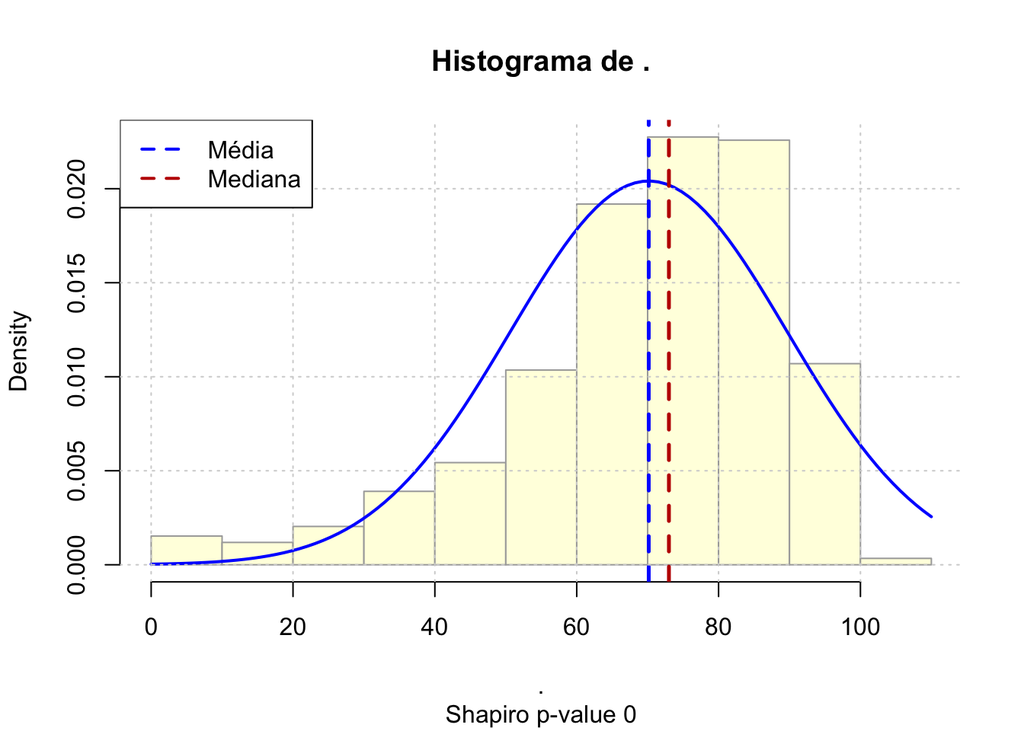

```r
#
# Coisinhas bacanas que dá pra fazer no R
# A função a seguir redefine a função histograma padrão colocando novas cores e
# desenhando uma distribuição normal superimposta ao histograma
mhist = function(xx, linecol = "blue", lwd = 2, col = "lightyellow", border = "darkgray", normdist = TRUE, main = NULL, xlab = deparse(substitute(xx)), expdist = FALSE, breaks = sqrt(length(xx))/2, ...) {
  xxx = seq(min(xx), max(xx), length.out = 100)
  if(is.null(main)) main = paste0("Histograma de ", deparse(substitute(xx)))
  yyy = 0
  yyy2 = 0
  if(normdist) yyy = dnorm(xxx, mean(xx), sd(xx))
  if(expdist) yyy2 = dexp(xxx, 1/mean(xx))
  h = graphics::hist(x = xx, ..., plot = FALSE, breaks = breaks)
  sub = ""
  if(normdist) sub = paste("Shapiro p-value", (shapiro.test(xx)$p.value %>% round(2)), collapse = " = ")
  h = graphics::hist(x = xx, ..., freq = FALSE, plot = TRUE, ylim = c(0, max(c(h$density, yyy, yyy2))), col = col, border = border, sub = sub, main = main, xlab = xlab, breaks = breaks)
  if(normdist) {
    curve(dnorm(x, mean(xx), sd(xx)), add = TRUE, col = linecol, lwd = lwd)
  }
  if(expdist) {
    curve(dexp(x, 1/mean(xx)), add = TRUE, col = linecol, lwd = lwd)
  }
  abline(v = mean(xx), col = "blue", lwd = 2.5, lty = 2)
  abline(v = median(xx), col = "#C00000", lwd = 2.5, lty = 2)
  grid()
  legend("topleft", legend = c("Média", "Mediana"), col = c("blue", "#C00000"), lty = 2, lwd = 2)
}
# redefino a função hist
hist = mhist
# Faço um histograma simples
idades %>% hist
```

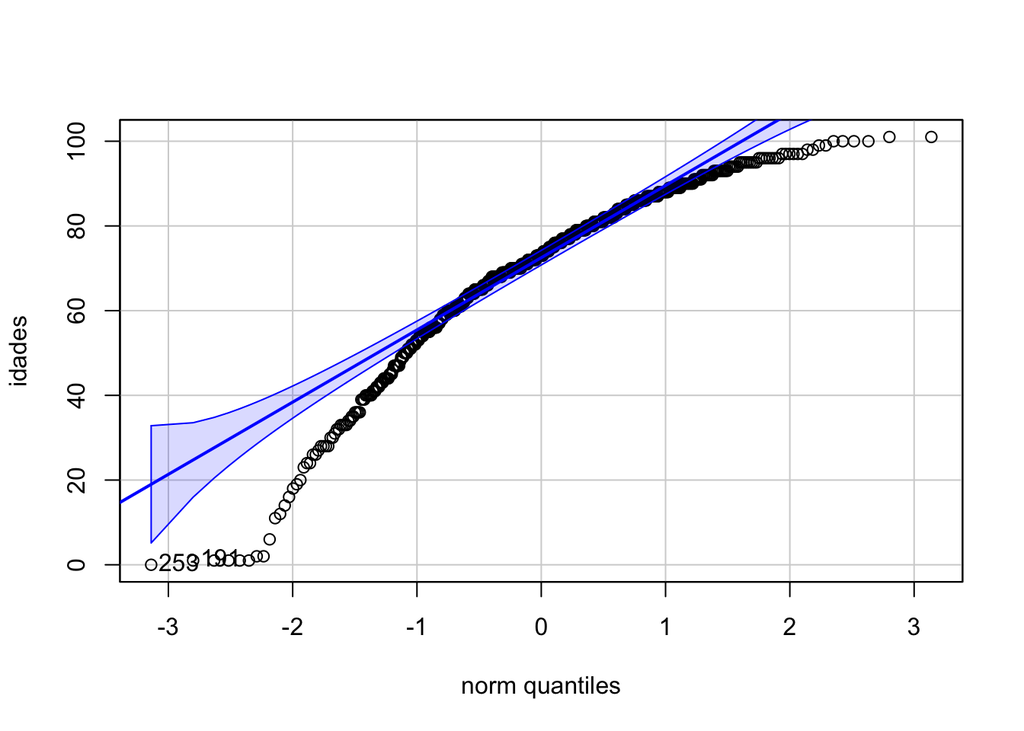

```
## [1] 253 191
```

```r
# Verifico a presença de outliers na distribuição
car::qqPlot(idades)
```

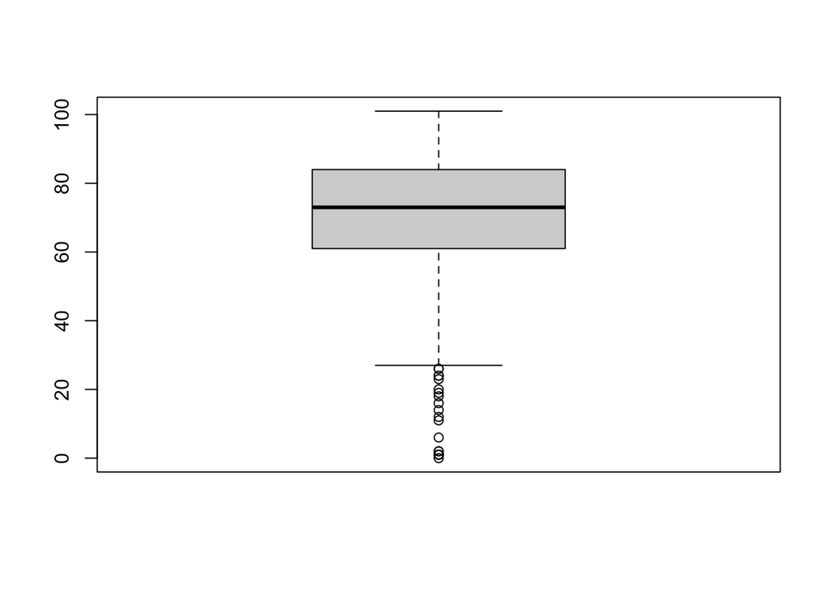

```r
b = boxplot(idades, range = 1.5)
```

```r
# Pelo boxplot percebemos que há vários candidatos a outliers inferiores, ou seja, mais pessoas
# jovens morrendo do que seria de se esperar
# estes são os valores apontados como candidatos a outliers
b$out
```

```
##  [1] 12 18 11 26  2 26 24 20  1  6  0  2 19  1 16  1  1  1 24 14 23
```

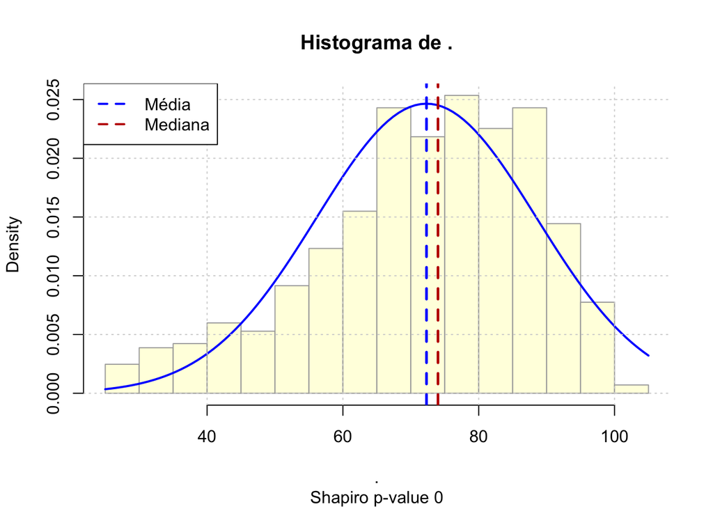

```r
# Removo esses candidatos a outliers da amostra
w = which(idades%in%b$out)
idades.1 <- idades[-w]
# Faço novo histograma simples
idades.1 %>% hist
```

```r
c(summary(idades.1), n = idades.1 %>% length)
```

```
##      Min.   1st Qu.    Median      Mean   3rd Qu.      Max.         n
##  27.00000  63.00000  74.00000  72.30986  85.00000 101.00000 568.00000
```

```r
# Diferentes testes de normalidade nos darão diferentes resultados...
shapiro.test(idades.1)
```

```
##
##  Shapiro-Wilk normality test
##
## data:  idades.1
## W = 0.96241, p-value = 7.163e-11
```

```r
moments::jarque.test(idades.1)
```

```
##
##  Jarque-Bera Normality Test
##
## data:  idades.1
## JB = 39.783, p-value = 2.297e-09
## alternative hypothesis: greater
```

```r
nortest::ad.test(idades.1)
```

```
##
##  Anderson-Darling normality test
##
## data:  idades.1
## A = 5.2043, p-value = 7.256e-13
```

```r
nortest::cvm.test(idades.1)
```

```
##
##  Cramer-von Mises normality test
##
## data:  idades.1
## W = 0.75196, p-value = 2.798e-08
```

```r
nortest::lillie.test(idades.1)
```

```
##
##  Lilliefors (Kolmogorov-Smirnov) normality test
##
## data:  idades.1
## D = 0.074599, p-value = 5.556e-08
```

```r
nortest::pearson.test(idades.1)
```

```
##
##  Pearson chi-square normality test
##
## data:  idades.1
## P = 93.444, p-value = 1.865e-10
```

```r
nortest::sf.test(idades.1)
```

```
##
##  Shapiro-Francia normality test
##
## data:  idades.1
## W = 0.96379, p-value = 1.476e-09
```

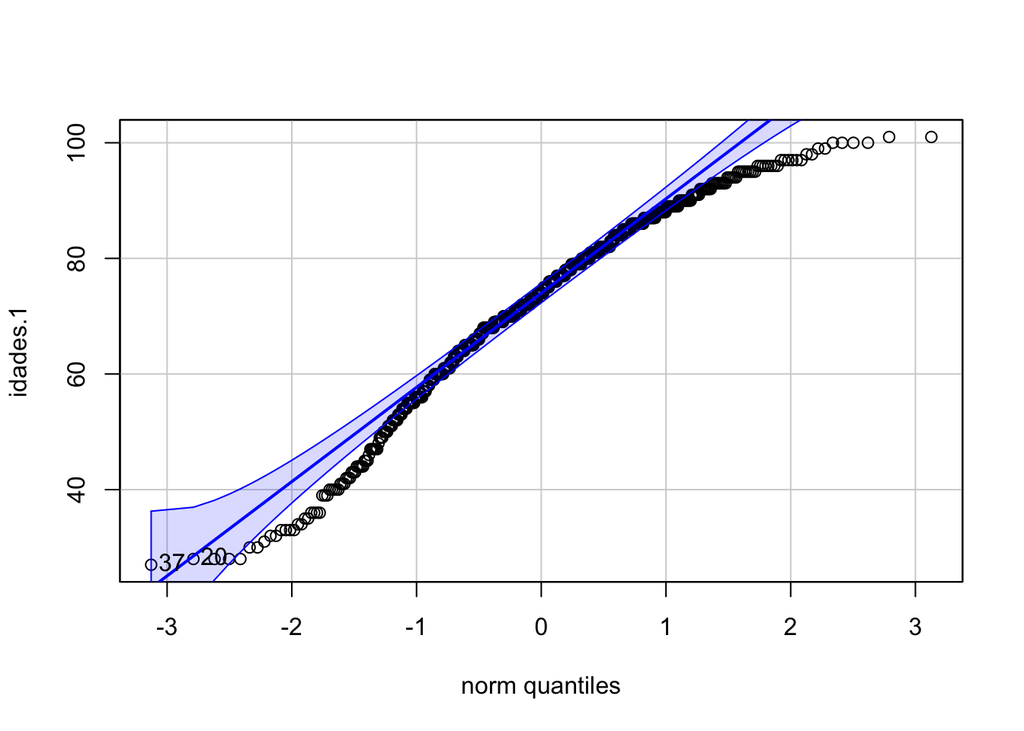

```
## [1] 37 20
```

```r
car::qqPlot(idades.1)
```

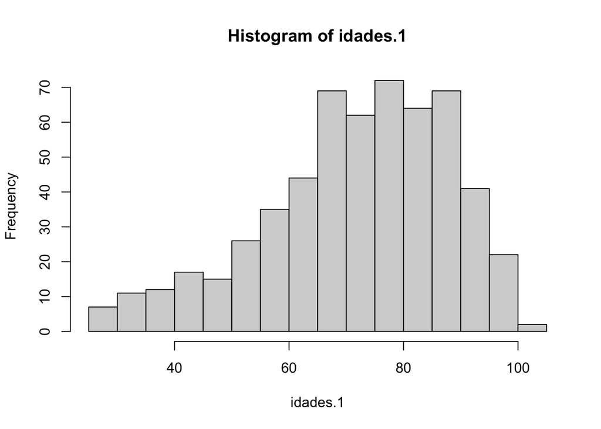

```r
#
# Aqui a gente usa a função padrão
hist = graphics::hist
hist(idades.1)
```

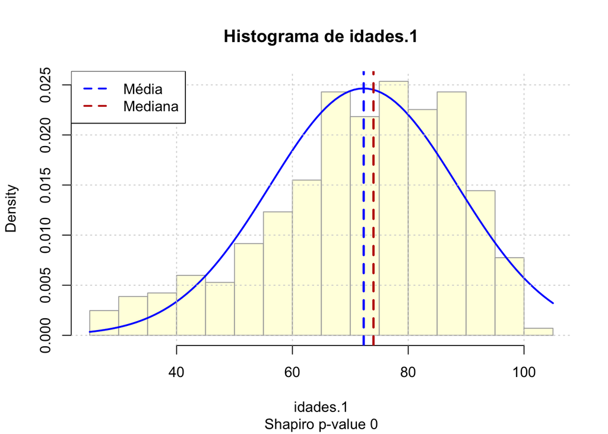

```r
#
# Aqui a gente troca a função padrão pela função redefinida
hist = mhist
hist(idades.1)
```

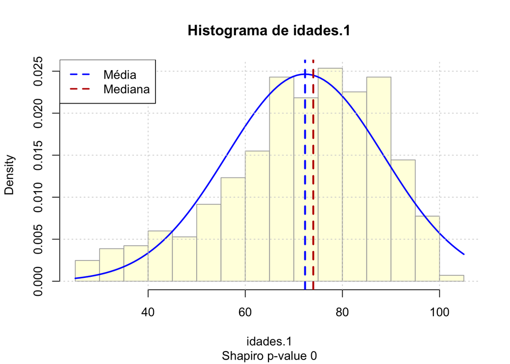

```r
# Também podemos chamar diretamente a função redefinida
mhist(idades.1)
```

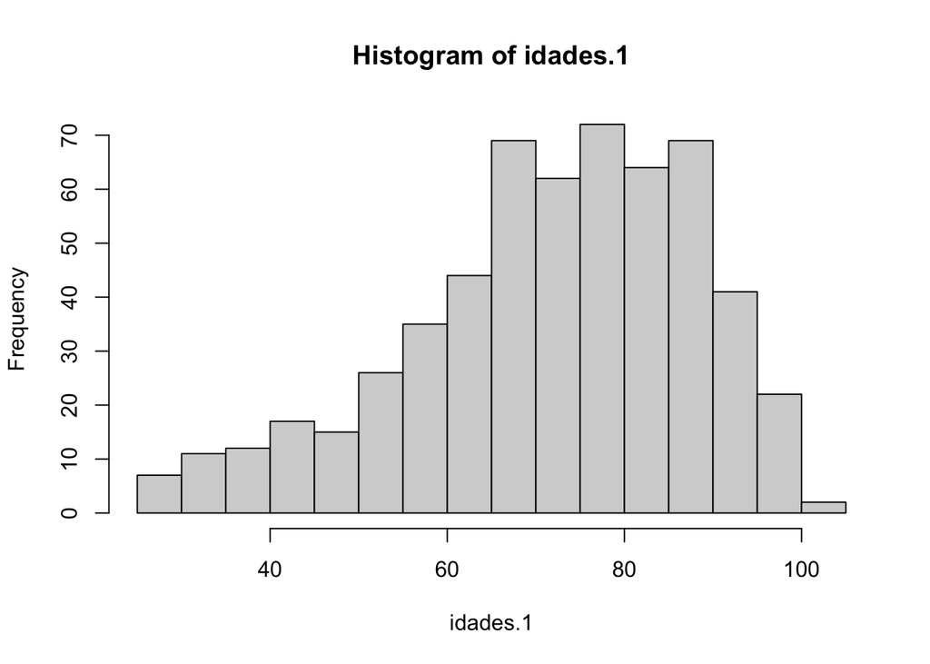

```r
#
# Aqui a gente volta a usar a função padrão
hist = graphics::hist
hist(idades.1)
```

Por vezes, para analisar o conjunto completo de dados e obter maior qualidade estatística, fazemos uso de transformações. Por exemplo, dados que exibem assimetria negativa costumam se comportar melhor quando elevados a uma potência

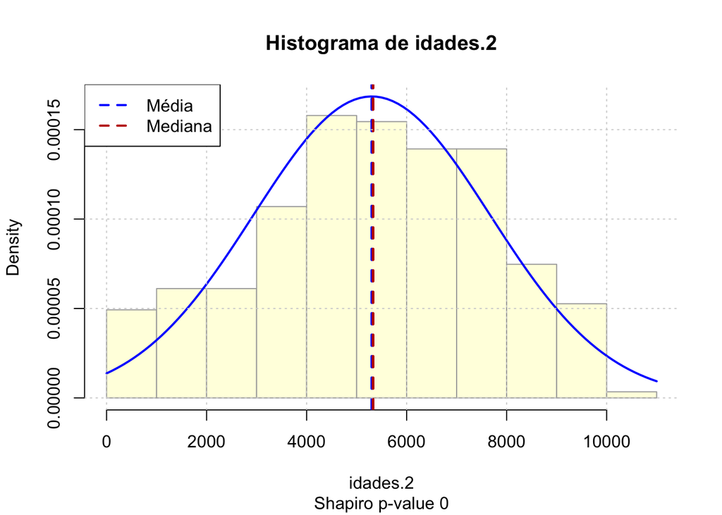

```r
# Pegamos o conjunto original com forte assimetria negativa e elevamos os seus valores
# ao quadrado
idades.2 = idades^2
mhist(idades.2)
```

```r
shapiro.test(idades.2)
```

```
##
##  Shapiro-Wilk normality test
##
## data:  idades.2
## W = 0.98357, p-value = 3.422e-06
```

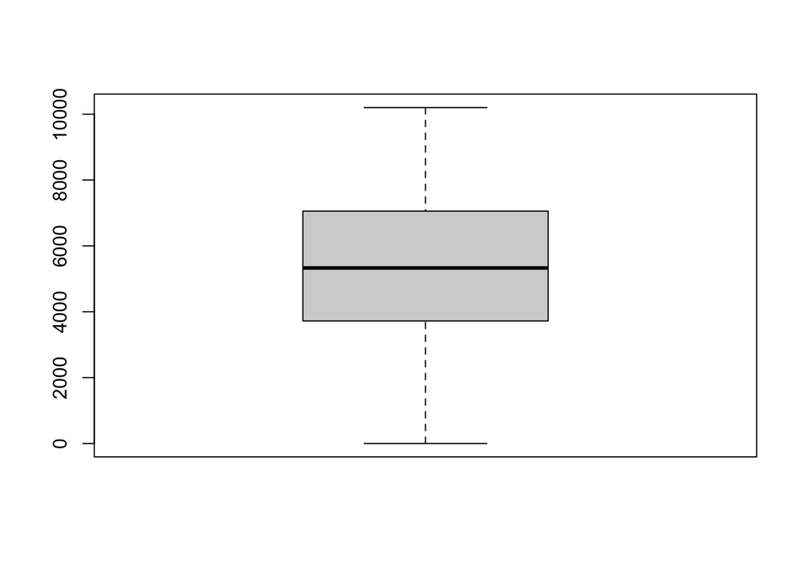

```r
boxplot(idades.2)
```

```r
nortest::pearson.test(idades.2)
```

```
##
##  Pearson chi-square normality test
##
## data:  idades.2
## P = 96.756, p-value = 5.086e-11
```

```r
# Assimetria dos conjuntos de dados
lapply(list(idades, idades.1, idades.2), moments::skewness) %>% unlist
```

```
## [1] -1.1624293 -0.6476510 -0.2535672
```

```r
# Achatamento (curtose) dos conjuntos de dados (centrado em 3)
lapply(list(idades, idades.1, idades.2), moments::kurtosis) %>% unlist
```

```
## [1] 4.530584 2.943723 2.425554
```

```r
# Excesso de curtose dos conjuntos de dados (centrado em 0)
lapply(list(idades, idades.1, idades.2), e1071::kurtosis) %>% unlist
```

```
## [1]  1.51521308 -0.06663328 -0.58267563
```

# 7 Diferentes linguagens podem ser usadas

Vamos calcular o somatório das raízes quadradas dos primeiros 10 milhões de números naturais

## 7.1 Em `Julia` é mais rápido que em…

```julia
@time let
  a = 1:10000000
  y = 0
  for i in a
    y += sqrt(i);
  end
  y
end
```

```
##   0.057644 seconds
```

```
## 2.1081852648716972e10
```

## 7.2 Em `R`, que é mais rápido que em…

```r
start = Sys.time()
a = 0
for(i in 1:10000000) {
  a = a + sqrt(i)
}
a %>% sprintf("%15.6f", .) %>% cat
```

```
## 21081852648.716972
```

```r
end = Sys.time()
cat("\n", end-start, " segundos", sep = "")
```

```
##
## 0.1468029 segundos
```

```r
start = Sys.time()
1:10000000 %>% sqrt %>% sum
```

```
## [1] 21081852649
```

```r
end = Sys.time()
cat("\n", end-start, " segundos", sep = "")
```

```
##
## 0.1838801 segundos
```

## 7.3 Em `Python`

```python
import timeit
start = timeit.default_timer()
import numpy as np
a = 0
for i in range(1, 10000001):
  a += np.sqrt(i)
a
```

```
## 21081852648.716972
```

```python
end = timeit.default_timer()
print("{:.7f}".format(end-start) + " segundos")
```

```
## 6.3134108 segundos
```

# 8 Regressão Linear

A regressão linear em sua forma matricial pode ser descrita como

$$\mathbf{X}=\left[\matrix{
1&x_{1,1}&x_{1,2}&\dots&x_{1,k}\\
1&x_{2,1}&x_{2,2}&\dots&x_{2,k}\\
\vdots&\vdots&\vdots&\ddots&\vdots\\
1&x_{n-1,1}&x_{n-1,2}&\dots&x_{n-1,k}\\
1&x_{n,1}&x_{n,2}&\dots&x_{n,k}
}\right]\quad
\mathbf{b} = \left[\matrix{
b_0\\
b_1\\
\vdots\\
b_{k-1}\\
b_k
}\right]\quad
\mathbf{y} = \left[\matrix{
y_0\\
y_1\\
\vdots\\
y_{n-1}\\
y_n
}\right]\\\ \\[2em]\\[1em]
\mathbf{Xb = y}\\[1em]
\mathbf{X'Xb = X'y}\\[1em]
\mathbf{(X'X)^{-1}X'Xb = (X'X)^{-1}X'y}\\[1em]
\mathbf{Ib = (X'X)^{-1}X'y}\\[1em]
\mathbf{b = (X'X)^{-1}X'y}\\[1em]
\mathbf{\widehat{y} = Xb}\\[1em]
\mathbf{e=y-\widehat{y}}\\[1em]
n = \dim({\mathbf{X}})[1]\\[1em]
k = \dim({\mathbf{X}})[2]\\[1em]
SSE = \mathbf{e'e}\\[1em]
glE = n-k\\[1em]
\sigma^2 = SSE/glE\\[1em]
SSTr = \sum(\widehat{y}_i-\bar{y})^2\\[1em]
glTr = k-1\\[1em]
F = \dfrac{SSTr/glTr}{SSE/glE}\\[2em]
\text{se}_i=\sqrt{\sigma^2\left[\mathbf{(X'X)^{-1}}\right]_{ii}}\\[1.5em]
t_i = b_i/\text{se}_i\\[1em]
R^2 = 1-\dfrac{SSE}{SSTr+SSE}\\[2em]
R^2_{aj} = 1-\left[\left(1-R^2\right)\dfrac{n-1}{n-k}\right]$$
Tomando um caso exemplo

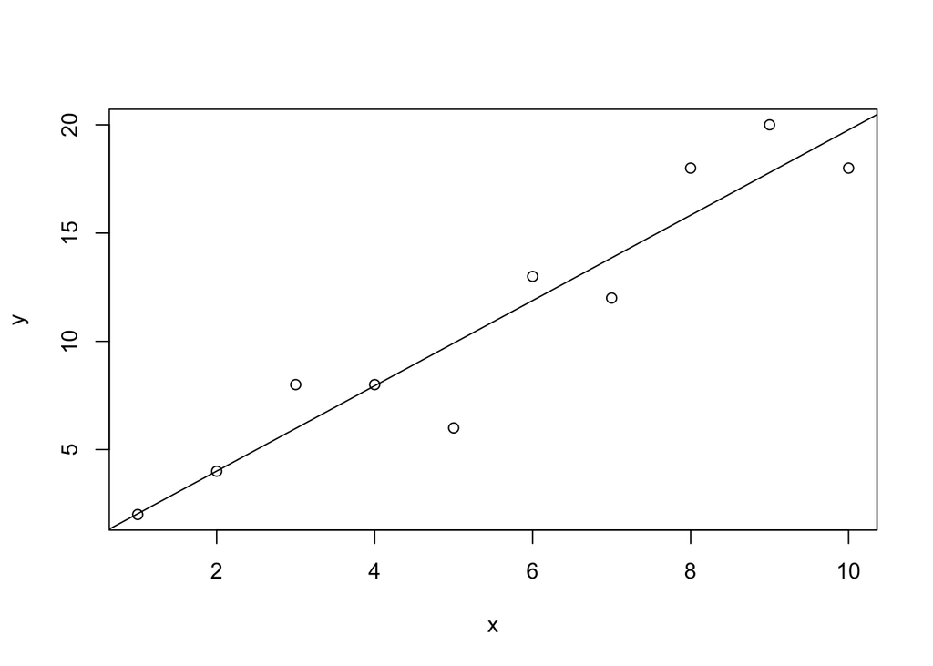

```r
set.seed(33)
x = 1:10
y = 2*x + rnorm(x)*2
y = round(y, 0)
plot(x, y); m = lm(y~x); abline(m)
```

Vamos aos cálculos

```r
# Montando a matrix X
(X = cbind(1, x))
```

```
##          x
##  [1,] 1  1
##  [2,] 1  2
##  [3,] 1  3
##  [4,] 1  4
##  [5,] 1  5
##  [6,] 1  6
##  [7,] 1  7
##  [8,] 1  8
##  [9,] 1  9
## [10,] 1 10
```

```r
# vetor y
y %>% matrix(ncol = 1)
```

```
##       [,1]
##  [1,]    2
##  [2,]    4
##  [3,]    8
##  [4,]    8
##  [5,]    6
##  [6,]   13
##  [7,]   12
##  [8,]   18
##  [9,]   20
## [10,]   18
```

```r
# transpondo
Xt = t(X)
# multiplicando
XtX = Xt%*%X
# Invertendo
XtXm1 = solve(XtX)
# Multiplicando pela transposta
XtXm1Xt = XtXm1%*%Xt
# calculando os coeficientes
b = XtXm1Xt%*%y
b
```

```
##         [,1]
##   0.06666667
## x 1.96969697
```

```r
# calculando valores previstos
yhat = X%*%b
# erros
e = y - yhat
# quadrados dos erros, dos tratamentos e os respectivos graus de liberdade
SSE = sum(e^2)
glE = nrow(X)-ncol(X)
SSTr = sum((yhat - mean(y))^2)
glTr = ncol(X)-1
# erro-padrão da regressão
sigma2 = SSE/glE
se = sqrt(sigma2)
se
```

```
## [1] 2.145467
```

```r
# Estatística F do teste ANOVA de regressão
(SSTr/glTr)/(SSE/glE)
```

```
## [1] 69.53588
```

```r
# Coeficiente de determinação (bruto e ajustado)
(R2 = 1-SSE/(SSE+SSTr))
```

```
## [1] 0.896822
```

```r
(R2aj = 1-(1-R2)*(nrow(X)-1)/(glE))
```

```
## [1] 0.8839247
```

```r
# erros-padrão dos coeficientes
((sigma2*XtXm1) %>% diag %>% sqrt -> se)
```

```
##                   x
## 1.4656332 0.2362082
```

```r
# estatísticas t dos coeficientes
(b/se -> t)
```

```
##        [,1]
##   0.0454866
## x 8.3388176
```

```r
# compare com os valores da função padrão
summary(m)
```

```
##
## Call:
## lm(formula = y ~ x)
##
## Residuals:
##     Min      1Q  Median      3Q     Max
## -3.9152 -1.3318  0.0242  1.7970  2.2061
##
## Coefficients:
##             Estimate Std. Error t value Pr(>|t|)
## (Intercept)  0.06667    1.46563   0.045    0.965
## x            1.96970    0.23621   8.339 3.24e-05 ***
## ---
## Signif. codes:  0 '***' 0.001 '**' 0.01 '*' 0.05 '.' 0.1 ' ' 1
##
## Residual standard error: 2.145 on 8 degrees of freedom
## Multiple R-squared:  0.8968, Adjusted R-squared:  0.8839
## F-statistic: 69.54 on 1 and 8 DF,  p-value: 3.236e-05
```

# 9 O quanto uma regressão pode explicar um fenômeno?

## 9.1 Este é o fenômeno definido por 4 pontos

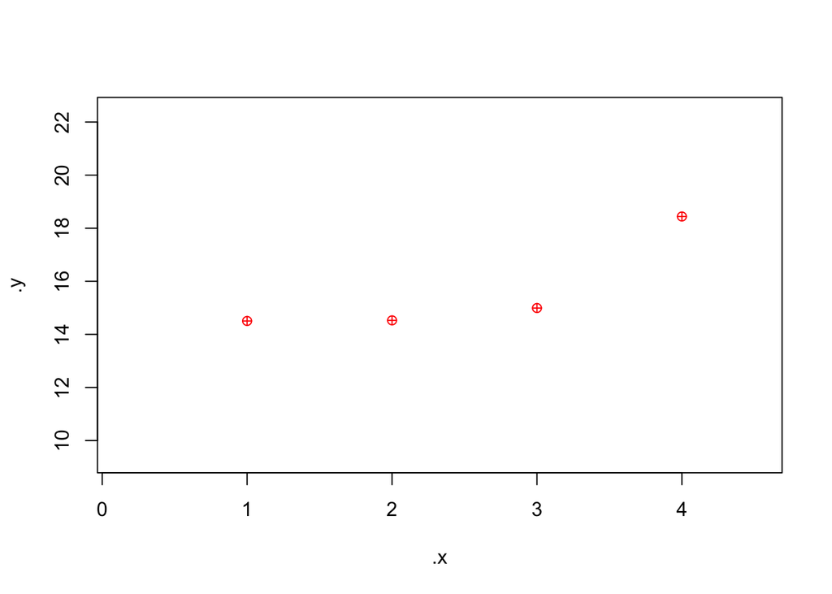

```r
set.seed(3141592)
x = 1:4
ok = FALSE
while(!ok){
  y = runif(4, 10, 20)
  lm(y~x+I(x^2)+I(x^3)) -> m
  m %>% coef -> cf
  ok = abs(cf[2]/cf[4]) < 10
}
.xx = seq(0, 5, length.out = 300)
.yy = cbind(1, .xx, .xx^2, .xx^3) %*% cf
.x = rnorm(300, 2.5, 0.8)
.y = (cbind(1, .x, .x^2, .x^3) %*% cf)
.y = .y+(range(.y) %>% diff)/5*rnorm(.y)
# este é o fenômeno
plot(.x, .y, type = "n")
#lines(.xx, .yy, col = "red", lwd = 2)
points(x, y, col = "red", pch = 10)
```

## 9.2 A curva polinomial exata que passa pelos 4 pontos

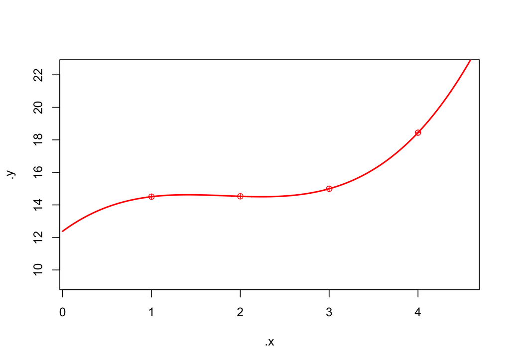

```r
plot(.x, .y, type = "n")
lines(.xx, .yy, col = "red", lwd = 2)
points(x, y, col = "red", pch = 10)
```

## 9.3 Pontos aleatórios gerados com base no fenômeno

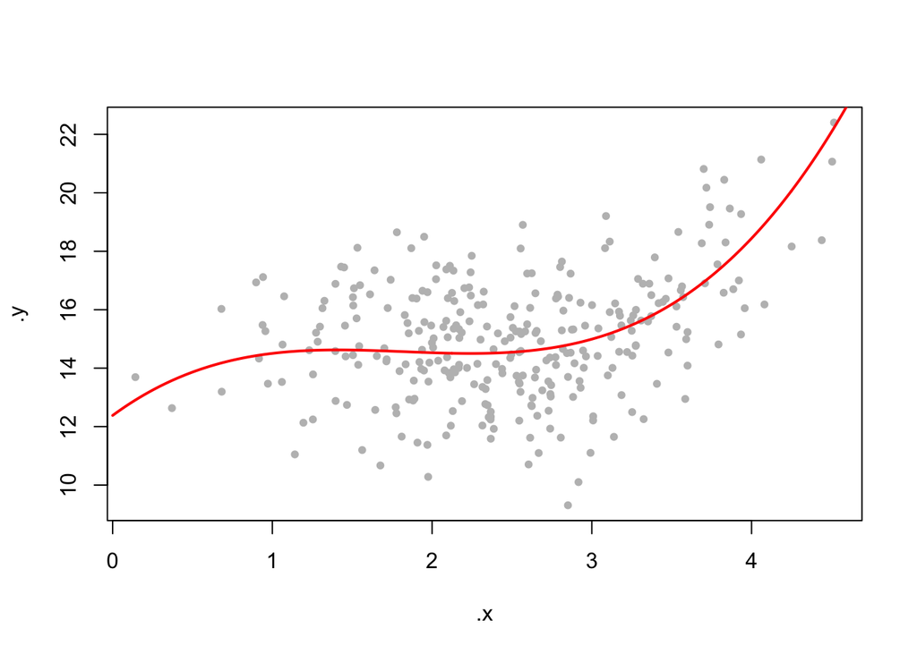

```r
# estes são pontos aleatórios gerados em torno do fenômeno
plot(.x, .y, pch = 20, col = "gray")
lines(.xx, .yy, col = "red", lwd = 2)
```

## 9.4 Cálculo do polinômio de regressão

### 9.4.1 Escolha do modelo

```r
#lines(.xx, .yy, col = "red")
.xxx = seq(min(.x), max(.x), length.out = 300)
lm(.y~.x) -> m1
lmtest::reset(m1)
```

```
##
##  RESET test
##
## data:  m1
## RESET = 28.667, df1 = 2, df2 = 296, p-value = 4.167e-12
```

```r
lm(.y~.x+I(.x^2)) -> m2
lmtest::reset(m2)
```

```
##
##  RESET test
##
## data:  m2
## RESET = 5.223, df1 = 2, df2 = 295, p-value = 0.005901
```

```r
lm(.y~.x+I(.x^2)+I(.x^3)) -> m
lmtest::reset(m)
```

```
##
##  RESET test
##
## data:  m
## RESET = 1.5476, df1 = 2, df2 = 294, p-value = 0.2145
```

```r
lm(.y~.x+I(.x^2)+I(.x^3)+I(.x^4)) -> m4
lmtest::reset(m4)
```

```
##
##  RESET test
##
## data:  m4
## RESET = 1.4347, df1 = 2, df2 = 293, p-value = 0.2398
```

```r
lm(.y~.x+I(.x^2)+I(.x^3)+I(.x^4)+I(.x^5)) -> m5
lmtest::reset(m5)
```

```
##
##  RESET test
##
## data:  m5
## RESET = 1.8493, df1 = 2, df2 = 292, p-value = 0.1592
```

```r
lapply(list(m1, m2, m, m4, m5), broom::glance) %>% as.data.frame() %>% matrix(nrow = 5, byrow = 1) -> aicbic
aicbic = aicbic[,c(2, 9:10)]
colnames(aicbic) = c("R2aj", "AIC", "BIC")
rownames(aicbic) = paste(1:5, "º grau", sep = "")
# R2, AIC e BIC
aicbic
```

```
##         R2aj       AIC      BIC
## 1º grau 0.08888366 1279.434 1180.448
## 2º grau 0.1882621  1249.482 1048.163
## 3º grau 0.2315683  1237.726 988.903
## 4º grau 0.232889   1241.899 983.8682
## 5º grau 0.2356559  1245.5   976.9964
```

```r
# Teste ANOVA
anova(m1, m2, m, m4, m5)
```

```
## Analysis of Variance Table
##
## Model 1: .y ~ .x
## Model 2: .y ~ .x + I(.x^2)
## Model 3: .y ~ .x + I(.x^2) + I(.x^3)
## Model 4: .y ~ .x + I(.x^2) + I(.x^3) + I(.x^4)
## Model 5: .y ~ .x + I(.x^2) + I(.x^3) + I(.x^4) + I(.x^5)
##   Res.Df     RSS Df Sum of Sq       F    Pr(>F)
## 1    298 1180.45
## 2    297 1048.16  1   132.284 39.8074 1.028e-09 ***
## 3    296  988.90  1    59.260 17.8328 3.220e-05 ***
## 4    295  983.87  1     5.035  1.5151    0.2193
## 5    294  977.00  1     6.872  2.0679    0.1515
## ---
## Signif. codes:  0 '***' 0.001 '**' 0.01 '*' 0.05 '.' 0.1 ' ' 1
```

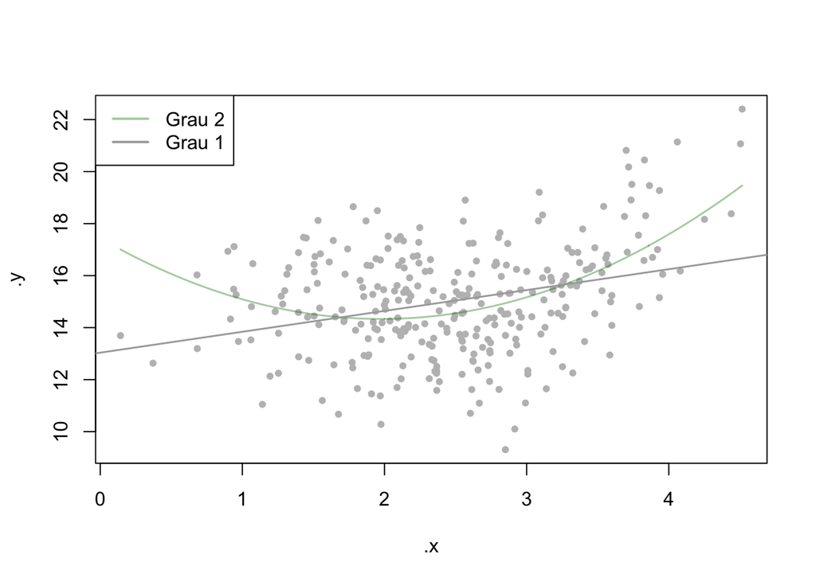

```r
.y2 = predict(m2, data.frame(.x = .xxx))
.yyy = predict(m, data.frame(.x = .xxx))
.yyyy = predict(m4, data.frame(.x = .xxx))
.yyyyy = predict(m5, data.frame(.x = .xxx))
plot(.x, .y, pch = 20, col = "gray")
lines(.xxx, .y2, col = "#00800060", lwd = 1.5)
abline(m1, col = "darkgray", lwd = 1.5)
legend("topleft", legend = paste("Grau", 5:1)[4:5], col = c("green", "maroon", "blue", "#00800060", "darkgray")[4:5], lwd = 2)
```

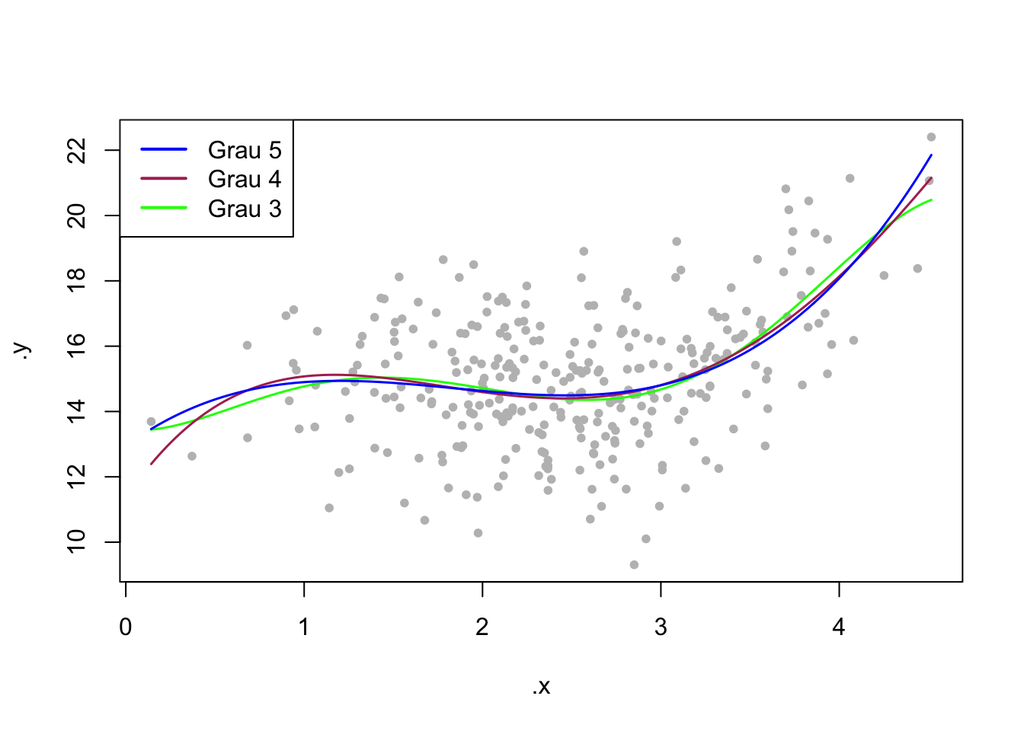

```r
plot(.x, .y, pch = 20, col = "gray")
lines(.xxx, .yyyyy, col = "green", lwd = 1.5)
lines(.xxx, .yyyy, col = "maroon", lwd = 1.5)
lines(.xxx, .yyy, col = "blue", lwd = 1.5)
legend("topleft", legend = paste("Grau", 5:1)[1:3], col = c("green", "maroon", "blue", "#00800060", "darkgray")[3:1], lwd = 2)
```

O $R^2$ aumenta para cada regressão e o BIC melhora, mas o AIC piora a partir do grau 4, ou seja, a escolha do AIC é o grau 3.

O teste ANOVA indica que não há melhora significativa a partir do grau 3, ou seja, os graus 4 e 5 introduzem uma complexidade desnecessária à explicação do fenômeno.

```r
library(stargazer)
stargazer(m1, m2, m, m4, m5, type = "html", font.size = "small", report = "vcp*", star.char = "•", notes = "<small>Os coeficientes de graus 4 e 5 perdem significância, ou seja, não melhoram a explicação do fenômeno, então ficamos com o grau 3.</small>", notes.append = FALSE, notes.align = "l")
```

[output not shown]

### 9.4.2 Como o polinômio de regressão aproxima o fenômeno

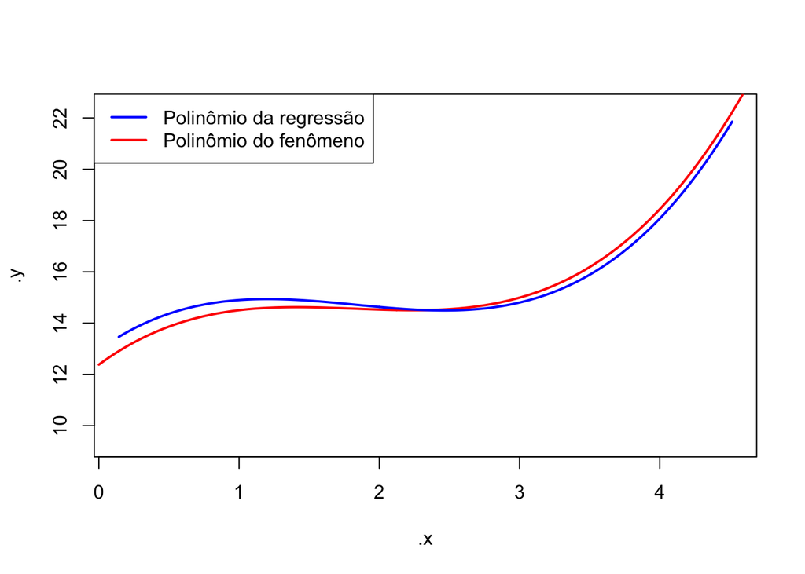

```r
plot(.x, .y, type = "n")
lines(.xx, .yy, col = "red", lwd = 2)
lines(.xxx, .yyy, col = "blue", lwd = 2)
legend("topleft", legend = c("Polinômio da regressão", "Polinômio do fenômeno"), col = c("blue", "red"), lwd = 2)
```

### 9.4.3 Comparativo dos coeficientes

```r
# coeficientes do fenômeno
cf
```

```
## (Intercept)           x      I(x^2)      I(x^3)
##  12.3816688   4.0211790  -2.3215244   0.4237429
```

```r
# coeficientes calculados pela regressão
m %>% summary
```

```
##
## Call:
## lm(formula = .y ~ .x + I(.x^2) + I(.x^3))
##
## Residuals:
##     Min      1Q  Median      3Q     Max
## -5.3368 -1.1544  0.0434  1.2572  4.3999
##
## Coefficients:
##             Estimate Std. Error t value Pr(>|t|)
## (Intercept)  12.9510     1.3208   9.805  < 2e-16 ***
## .x            3.9437     1.8001   2.191   0.0292 *
## I(.x^2)      -2.4385     0.7780  -3.134   0.0019 **
## I(.x^3)       0.4432     0.1052   4.212 3.37e-05 ***
## ---
## Signif. codes:  0 '***' 0.001 '**' 0.01 '*' 0.05 '.' 0.1 ' ' 1
##
## Residual standard error: 1.828 on 296 degrees of freedom
## Multiple R-squared:  0.2393, Adjusted R-squared:  0.2316
## F-statistic: 31.03 on 3 and 296 DF,  p-value: < 2.2e-16
```

```r
# diferenças percentuais
(abs(m$coefficients-cf)/abs(m$coefficients)*100) %>% round(1)
```

```
## (Intercept)          .x     I(.x^2)     I(.x^3)
##         4.4         2.0         4.8         4.4
```

## 9.5 Vamos ver os resíduos

```r
# Os resíduos são normais
shapiro.test(m$residuals)
```

```
##
##  Shapiro-Wilk normality test
##
## data:  m$residuals
## W = 0.99644, p-value = 0.7419
```

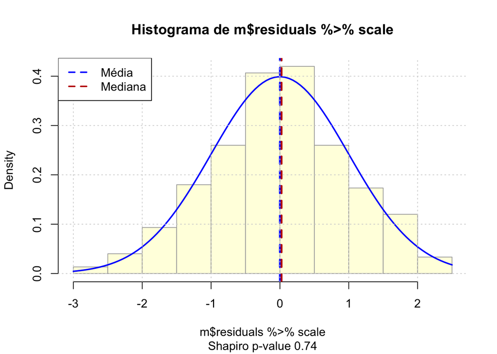

```r
mhist(m$residuals %>% scale)
```

```r
# Não temos condição de heteroscedasticidade
lmtest::bptest(m)
```

```
##
##  studentized Breusch-Pagan test
##
## data:  m
## BP = 0.91062, df = 3, p-value = 0.8229
```

## 9.6 Conclusão

Mesmo com um elevado nível de ruído, com um $R^2\approx23.16$%, observa-se uma boa aproximação da explicação do fenômeno por meio da regressão.

Este é um caso onde tem-se uma previsão ruim (por conta do $R^2$ baixo) mas uma boa explicação (a regressão aproximou adequadamente o fenômeno estudado).

# 10

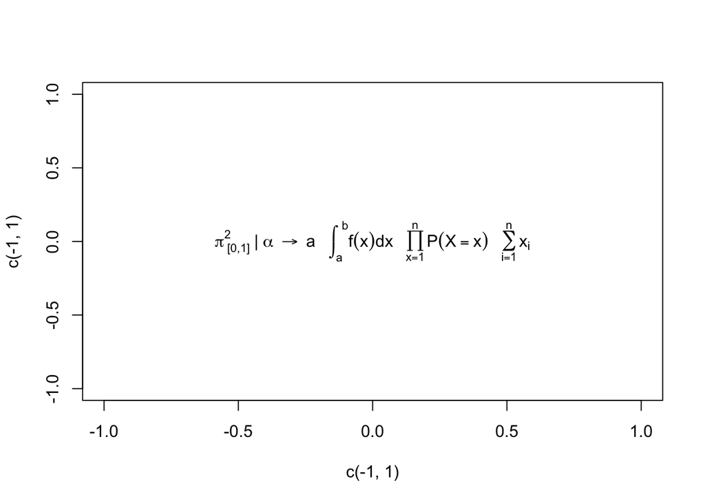

```r
plot(c(-1, 1), c(-1, 1), type = "n")
text(0, 0, expression(displaystyle(pi)[~"["*0*","*1*"]"]^2~"|"~alpha~""%->%~a~~~integral(f(x)*dx, a, b)~~~prod(plain(P)(X==x), x==1, n)~~~sum(x[i], i==1, n)), cex = 1)
```

```r
rho12 = 0.8; rho13 = 0.7; rho14 = 0.9
rho23 = 0.7; rho24 = 0.8;
rho34 = 0.92
c(1, rho12, rho13, rho14,
  rho12, 1, rho23, rho24,
  rho13, rho23, 1, rho34,
  rho14, rho24, rho34, 1) %>% matrix(nrow = 4) -> s
MASS::mvrnorm(500, mu = rep(0, 4), Sigma = s) -> dados

y = dados %*% c(0.3, 0.4, 0.5, 0.6) + 3*rnorm(500)

df = data.frame(y, dados)

df
```

[output not shown]

[output cut: 486 more lines]

```r
lm(y~., df) %>% summary
```

```
##
## Call:
## lm(formula = y ~ ., data = df)
##
## Residuals:
##     Min      1Q  Median      3Q     Max
## -8.2868 -2.1219 -0.0613  2.1796  9.0455
##
## Coefficients:
##             Estimate Std. Error t value Pr(>|t|)
## (Intercept) -0.02256    0.13746  -0.164   0.8697
## X1          -0.56660    0.49295  -1.149   0.2509
## X2           0.44922    0.25701   1.748   0.0811 .
## X3           0.48011    0.51866   0.926   0.3551
## X4           1.32211    0.82908   1.595   0.1114
## ---
## Signif. codes:  0 '***' 0.001 '**' 0.01 '*' 0.05 '.' 0.1 ' ' 1
##
## Residual standard error: 3.071 on 495 degrees of freedom
## Multiple R-squared:  0.2269, Adjusted R-squared:  0.2207
## F-statistic: 36.33 on 4 and 495 DF,  p-value: < 2.2e-16
```

```r
cor(dados)
```

```
##           [,1]      [,2]     [,3]      [,4]
## [1,] 1.0000000 0.8172398 0.696818 0.8949488
## [2,] 0.8172398 1.0000000 0.721905 0.8181792
## [3,] 0.6968180 0.7219050 1.000000 0.9194860
## [4,] 0.8949488 0.8181792 0.919486 1.0000000
```

```r
princomp(dados) -> pc
pc$scores %>% cor %>% round(3) -> dadospc
df = data.frame(y, pc$scores)

lm(y~., df) %>% summary
```

```
##
## Call:
## lm(formula = y ~ ., data = df)
##
## Residuals:
##     Min      1Q  Median      3Q     Max
## -8.2868 -2.1219 -0.0613  2.1796  9.0455
##
## Coefficients:
##             Estimate Std. Error t value Pr(>|t|)
## (Intercept) -0.01245    0.13736  -0.091  0.92780
## Comp.1       0.88141    0.07581  11.626  < 2e-16 ***
## Comp.2      -0.64766    0.23930  -2.707  0.00703 **
## Comp.3      -0.42015    0.31359  -1.340  0.18092
## Comp.4      -1.06228    1.05075  -1.011  0.31253
## ---
## Signif. codes:  0 '***' 0.001 '**' 0.01 '*' 0.05 '.' 0.1 ' ' 1
##
## Residual standard error: 3.071 on 495 degrees of freedom
## Multiple R-squared:  0.2269, Adjusted R-squared:  0.2207
## F-statistic: 36.33 on 4 and 495 DF,  p-value: < 2.2e-16
```